# Математика - Итоговая работа

**Дедлайн: 19 марта 23:59**

## Задание:

В качестве итогового задания по блоку «Математика» мы предлагаем вам подготовить отчет с результатами обучения регрессионной модели. Для подготовки такого отчета от вас потребуется применить все знания и навыки, полученные за время прохождения блока. Несмотря на то, что есть ряд требований по оформлению решения и перечню проведенных тестов, мы будем рады, если вы проявите свою индивидуальность в исследуемых датасетах, выдвинутых гипотезах и дизайне.

#### Данные:

Для подготовки отчета мы предлагаем вам выбрать любой датасет, который:

- позволяет обучить регрессионную модель методом МНК с непрерывной зависимой переменной;
- будет содержать наблюдения с возможностью сегментации на 3 и более групп по какому-то/каким-то из признаков. В рамках тестирования гипотез и анализа распределений вам потребуется сравнивать между собой различные когорты пользователей/наблюдений;
- позволит протестировать ряд продуктовых/социальных гипотез, актуальных для текущих рыночных реалий. Ограничения по индустрии и описываемым процессам нет, это может быть датасет как из области телекома, банкинга, так и медицины, соц. опросов, какой-либо платформы и пр. За совпадение датасетов не предвидится никаких штрафов, но мы ожидаем, что у вас получится нас удивить и подобрать не самые популярные семплы данных.

**Размер датасета:** от 200 наблюдений, от 5 регрессоров в модели.

#### Задачи:

Перед выполнением задач ознакомьтесь с текстом всего экзамена, чтобы была возможность заранее продумать содержание отчета и согласованность между отдельными его блоками.

#### Теория вероятностей и мат. статистика

1. Провести анализ датасета на предмет распределений признаков и составить общую картину различия/сходства распределений по факторам между группами. Можно ограничиться простыми плотностями и PSI / KS.
2. Сформулировать и протестировать несколько гипотез касательно разницы сегментов (к примеру, пользователей) по нескольким показателям. Сделать заключение о наличии или отсутствии статистически значимой разницы. К каждой оценке разницы между группами построить точечную и интервальную оценку. Интервальную можно построить методом бутстрэпа.
3. Если какая-то группа хуже другой, то сформировать ряд продуктовых гипотез, почему такое могло произойти и предложить идеи, какие эксперименты можно было провести на отстающей группе для повышения показателей.

#### Регрессионный анализ

1. Оценить модель линейной регрессии методом МНК, подготовить репорт модели и проинтерпретировать оценки коэффициентов.
2. Провести тесты на гетероскедастичность, мультиколлинеарность (как визуальные, так и численные), дать комментарии по произведенным тестам. В случае нарушения предпосылок Гаусса-Маркова – принять соответствующие корректирующие модель действия, после чего повторить пункт 1.
3. В ходе анализа протестируйте как минимум 2 спецификации моделей. Финальная спецификация модели может включать не все факторы и не все наблюдения из исходной выборки. Продемонстрируйте на примере финальной и одной из промежуточных моделей, по каким критериям и метрикам был произведен выбор в пользу финальной спецификации. Дайте трактовку значениям этих критериев и метрик.

#### Визуализация

При оценке качества отчета будет учитываться не только его содержание, корректность применяемых методов, но и аккуратность, а также общая стилистика оформления.

Мы предлагаем вам:

- на каждый пункт экзамена иметь как минимум 1 график, построенный любой из библиотек;
- для наиболее важных/наглядных выводов использовать интерактивные графики вида plotly, чтобы донести читателю все особенности данных;
- к графикам необходимо добавлять описание, позволяющее раскрыть их контент (от одного предложения).

#### Перейду к выполнению задания

# Заработная плата и образование

## Исследовательские вопросы

**1. Исследовательский вопрос**

Существуют ли некоторые эмпирические предпосылки, что существует ряд факторов, оказывающих влияние на уровень заработной платы (в частности, оказывает ли влияние на уровень заработной платы дополнительный год образования (основной интерес в исследовании) / этническая принадлежность / прочие факторы.

Наиболее интересный для нас вопрос в области статистических гипотез - значимость расовой принадлежности для уровня заработной платы. В области регрессии - влияние дополнительного года образования на уровень заработной платы.

**2. Исследовательская гипотеза**

При увеличении уровня образования человека, соответствующе в некотором измерении растет его заработная плата. Расовая дискриминация как институциональная проблема существовала на горизонте сбора данных.

**3. Экономический механизм, который объясняет данные предположения**

Вопрос поиска некоторой формы зависимости, предпосылок к конкретному успеху в жизни, выражаемый денежным эквивалентом, всегда волновал исследователей-социологов/экономистов. Учитывая факторы того времени, логично предположить, что образование действительно оказывает значимое влияние на будущий в жизни успех. Образование есть фундамент, дающий не просто знания, а, в частности, некоторую форму социальных связей между выпускниками, которая и является краеугольным камнем "успешности" в будущей жизни. Прочие же факторы, как, например, этническая принадлежность, важны потому, что США 20-го века представляло собой крайне национализированное общество, только недавно отошедшее от сегрегационных принципов по этничности (и, в частности, расы). Соответственно, можно наглядно рассмотреть взаимосвязи и доказать, что расовая дискриминация на момент сбора данных действительно имела место быть.

## Модель

- **ММЛР, которая подходит для описания изучаемых взаимосвязей.**

Есть ряд линейных моделей, которые можно рассмотреть в данном исследовании. Лично я планирую ограничиться:

- Стандартной моделью линейной регрессии (потенциально, с робастными к гетероскедастичности ошибками)
- Log-level линейной регрессией (с прологарифмированным доходом для более удобной интепретацией)
- Потенциально, если буду видеть необходимость, линейной регрессией с инструментальными переменными (оценка через 2OLS)

## Набор данных

Набор данных взят в ходе работы с материалами исследования:  
**Card, D. (1993).** *Using geographic variation in college proximity to estimate the return to schooling.*

Работа доступна по [ссылке](https://www.nber.org/papers/w4483).

Также данные и другие материалы доступны на [странице автора](https://davidcard.berkeley.edu/data_sets.html).

```python
# Импорт необходимых библиотек

import numpy as np
import pandas as pd
import matplotlib.pyplot as plt
import seaborn as sns
import scipy.stats as stats
from scipy.stats import shapiro, mannwhitneyu
from statsmodels.api import add_constant, OLS
from statsmodels.stats.outliers_influence import variance_inflation_factor
from statsmodels.stats.sandwich_covariance import cov_hc1
from linearmodels.iv import IV2SLS
from sklearn.linear_model import Lasso
from sklearn.preprocessing import StandardScaler
from sklearn.model_selection import RandomizedSearchCV
from sklearn.metrics import mean_squared_error, r2_score
import statsmodels.api as sm
import statsmodels.stats.api as sms
```

```python
df = pd.read_csv('Card1993.txt', sep='\t')
```

```python
df.head()
```

|  | id | nearc2 | nearc4 | nearc4a | nearc4b | ed76 | ed66 | age76 | daded | nodaded | ... | noint80 | enroll76 | enroll78 | enroll80 | kww | iq | marsta76 | marsta78 | marsta80 | libcrd14 |
| --- | --- | --- | --- | --- | --- | --- | --- | --- | --- | --- | --- | --- | --- | --- | --- | --- | --- | --- | --- | --- | --- |
| 0 | 2 | 0 | 0 | 0 | 0 | 7 | 5 | 29 | 9.94 | 1 | ... | 0 | 0 | 0.0 | 0.0 | 15.0 | NaN | 1.0 | 1.0 | 1.0 | 0.0 |
| 1 | 3 | 0 | 0 | 0 | 0 | 12 | 11 | 27 | 8.00 | 0 | ... | 0 | 0 | 0.0 | 0.0 | 35.0 | 93.0 | 1.0 | 4.0 | 4.0 | 1.0 |
| 2 | 4 | 0 | 0 | 0 | 0 | 12 | 12 | 34 | 14.00 | 0 | ... | 1 | 0 | NaN | NaN | 42.0 | 103.0 | 1.0 | NaN | NaN | 1.0 |
| 3 | 5 | 1 | 1 | 1 | 0 | 11 | 11 | 27 | 11.00 | 0 | ... | 0 | 0 | NaN | 0.0 | 25.0 | 88.0 | 1.0 | NaN | 5.0 | 1.0 |
| 4 | 6 | 1 | 1 | 1 | 0 | 12 | 12 | 34 | 8.00 | 0 | ... | 1 | 0 | 0.0 | NaN | 34.0 | 108.0 | 1.0 | 1.0 | NaN | 0.0 |

5 rows × 52 columns

| Name | Label |
| --- | --- |
| id | sequential id runs from 1 to 5225 |
| nearc2 | grew up near 2-yr college |
| nearc4 | grew up near 4-yr college |
| nearc4a | grew up near 4-yr public college |
| nearc4b | grew up near 4-yr priv college |
| ed76 | education in 1976 |
| ed66 | education in 1966 |
| age76 | age in 1976 |
| daded | dads education missing=avg |
| nodaded | 1 if daded imputed |
| momed | moms education |
| nomomed | 1 if momed imputed |
| weight | nls weight for 1976 cross-section |
| momdad14 | 1 if live with mom and dad age 14 |
| sinmom14 | lived with single mom age 14 |
| step14 | lived step parent age 14 |
| reg661 | dummy for region=1 in 1966 |
| reg662 | dummy for region=2 in 1966 |
| reg663 | dummy for region=3 in 1966 |
| reg664 | dummy for region=4 in 1966 |
| reg665 | dummy for region=5 in 1966 |
| reg666 | dummy for region=6 in 1966 |
| reg667 | dummy for region=7 in 1966 |
| reg668 | dummy for region=8 in 1966 |
| reg669 | dummy for region=9 in 1966 |
| south66 | lived in south in 1966 |
| work76 | worked in 1976 |
| work78 | worked in 1978 |
| lwage76 | log wage (outliers trimmed) 1976 |
| lwage78 | log wage in 1978 outliers trimmed |
| famed | mom-dad education class 1-9 |
| black | 1 if black |
| smsa76r | in smsa in 1976 |
| smsa78r | in smsa in 1978 |
| reg76r | in south in 1976 |
| reg78r | in south in 1978 |
| reg80r | in south in 1980 |
| smsa66r | in smsa in 1966 |
| wage76 | raw wage cents per hour 1976 |
| wage78 | raw wage cents per hour 1978 |
| wage80 | raw wage cents per hour 1980 |
| noint78 | if noninterview in 1978 |
| noint80 | if noninterview in 1980 |
| enroll76 | 1 if enrolled in 1976 |
| enroll78 | 1 if enrolled in 1978 |
| enroll80 | 1 if enrolled in 1980 |
| kww | the kww score |
| iq | a normed iq score |
| marsta76 | mar status in 1976 1=married, spouse present |
| marsta78 | mar status in 1978 1=married, spouse present |
| marsta80 | mar status in 1980 1=married, spouse present |
| libcrd14 | 1 if library card in home age 14 |

### Предложение

В базовом состоянии набор данных представляет из себя задачу исследования взаимосвязи между заработной платой и образованием. Используемые методы, в частности, требуют IV (**Instrumental Variables**) подхода или же работой с алгоритмами, учитывающими автокорреляцию (которая возникает в этом наборе данных повсеместно).

Давайте упростим задачу - мы попробуем в качестве целевой переменной рассмотреть заработную плату на момент 1976-года (самая ранняя по годам отметка по заработной плате), основываясь на всех известных данных на тот момент (но не включающих в себя автокоррелированные данные).

Я считаю, что данная эвристика хоть и меняет контекст эмпирического исследования, но выступает отличным "упрощением" задачи для учебных целей.

Помимо этого, если будет необходимо, я дополнительно "упрощу" набор данных, если будет соответствующая необходимость.

Так, здесь снова же можно осуществить несколько корректировок, помимо автокоррелированных регрессоров. Давайте посмотрим на "подозрительные" регрессоры.

`id` - тут сразу оговорюсь, что для удобства просто исключу столбец из набора данных.

`nodaded` и `nomomed` - индикаторы того, что образование отца/матери было восстановлено (импутировано), т.е. данных не было, и вместо них использовали среднее. Значение 1 означает, что данные отсутствовали и были заменены, 0 — данные присутствовали. Крайне спорно использовать это как регрессор.

`weight` - NLS weight for 1976 cross-section (вес учитывает, насколько репрезентативно каждое наблюдение в данных относительно всей популяции). Снова же - крайне спорно использовать это как регрессор.

Теперь, проведя соответствующие корректировки, предлагаю снова взглянуть на анализируемый нами набор данных.

### Обработка набора данных

```python
columns = [
    "nearc2", "nearc4", "nearc4a", "nearc4b", "ed76", "age76", "daded",
    "momed", "momdad14", "sinmom14", "step14", "reg661", "reg662", "reg663",
    "reg664", "reg665", "reg666", "reg667", "reg668", "reg669", "south66",
    "work76", "lwage76", "wage76", "famed", "black", "smsa76r", "reg76r",
    "smsa66r", "enroll76", "kww", "iq", "marsta76", "libcrd14"
]
df = df[columns]
df.head()
```

|  | nearc2 | nearc4 | nearc4a | nearc4b | ed76 | age76 | daded | momed | momdad14 | sinmom14 | ... | famed | black | smsa76r | reg76r | smsa66r | enroll76 | kww | iq | marsta76 | libcrd14 |
| --- | --- | --- | --- | --- | --- | --- | --- | --- | --- | --- | --- | --- | --- | --- | --- | --- | --- | --- | --- | --- | --- |
| 0 | 0 | 0 | 0 | 0 | 7 | 29 | 9.94 | 10.25 | 1 | 0 | ... | 9 | 1 | 1 | 0 | 1 | 0 | 15.0 | NaN | 1.0 | 0.0 |
| 1 | 0 | 0 | 0 | 0 | 12 | 27 | 8.00 | 8.00 | 1 | 0 | ... | 8 | 0 | 1 | 0 | 1 | 0 | 35.0 | 93.0 | 1.0 | 1.0 |
| 2 | 0 | 0 | 0 | 0 | 12 | 34 | 14.00 | 12.00 | 1 | 0 | ... | 2 | 0 | 1 | 0 | 1 | 0 | 42.0 | 103.0 | 1.0 | 1.0 |
| 3 | 1 | 1 | 1 | 0 | 11 | 27 | 11.00 | 12.00 | 1 | 0 | ... | 6 | 0 | 1 | 0 | 1 | 0 | 25.0 | 88.0 | 1.0 | 1.0 |
| 4 | 1 | 1 | 1 | 0 | 12 | 34 | 8.00 | 7.00 | 1 | 0 | ... | 8 | 0 | 1 | 0 | 1 | 0 | 34.0 | 108.0 | 1.0 | 0.0 |

5 rows × 34 columns

| Name | Label | Description |
| --- | --- | --- |
| nearc2 | grew up near 2-yr college | Рос рядом с двухгодичным колледжем (потенциально влияет на доступность образования) |
| nearc4 | grew up near 4-yr college | Рос рядом с четырёхгодичным колледжем (может влиять на вероятность получения высшего образования) |
| nearc4a | grew up near 4-yr public college | Рос рядом с государственным четырёхгодичным колледжем (доступность образования по более низкой цене) |
| nearc4b | grew up near 4-yr priv college | Рос рядом с частным четырёхгодичным колледжем (возможность элитного образования) |
| ed76 | education in 1976 | Уровень образования на 1976 год (ключевая переменная, влияющая на доход) |
| age76 | age in 1976 | Возраст в 1976 году (может влиять на опыт работы и уровень зарплаты) |
| daded | dads education missing=avg | Уровень образования отца (если отсутствует, подставлено среднее значение) |
| momed | moms education | Уровень образования матери (влияет на семейное воспитание и образовательные возможности) |
| momdad14 | 1 if live with mom and dad age 14 | Проживал с обоими родителями в 14 лет (семейная стабильность) |
| sinmom14 | lived with single mom age 14 | Проживал с матерью-одиночкой в 14 лет (может указывать на возможные экономические трудности) |
| step14 | lived step parent age 14 | Проживал с отчимом/мачехой в 14 лет (фактор нестабильности семьи) |
| reg661 | dummy for region=1 in 1966 | Регион проживания в 1966 году (категориальная переменная) |
| reg662 | dummy for region=2 in 1966 | Регион проживания в 1966 году (категориальная переменная) |
| reg663 | dummy for region=3 in 1966 | Регион проживания в 1966 году (категориальная переменная) |
| reg664 | dummy for region=4 in 1966 | Регион проживания в 1966 году (категориальная переменная) |
| reg665 | dummy for region=5 in 1966 | Регион проживания в 1966 году (категориальная переменная) |
| reg666 | dummy for region=6 in 1966 | Регион проживания в 1966 году (категориальная переменная) |
| reg667 | dummy for region=7 in 1966 | Регион проживания в 1966 году (категориальная переменная) |
| reg668 | dummy for region=8 in 1966 | Регион проживания в 1966 году (категориальная переменная) |
| reg669 | dummy for region=9 in 1966 | Регион проживания в 1966 году (категориальная переменная) |
| south66 | lived in south in 1966 | Проживал на юге в 1966 году (может указывать на региональные различия в уровне доходов и образовании) |
| work76 | worked in 1976 | Работал в 1976 году (фактор занятости) |
| lwage76 | log wage (outliers trimmed) 1976 | Логарифм заработной платы в 1976 году (для учета неравномерного распределения зарплат) |
| famed | mom-dad education class 1-9 | Объединённый показатель уровня образования родителей (категориальная переменная) |
| black | 1 if black | Является ли респондент афроамериканцем (может отражать социальные и экономические различия) |
| smsa76r | in smsa in 1976 | Проживал в крупном городе (SMSA) в 1976 году (уровень урбанизации) |
| reg76r | in south in 1976 | Проживал на юге США в 1976 году (возможные региональные различия в зарплатах) |
| smsa66r | in smsa in 1966 | Проживал в крупном городе (SMSA) в 1966 году (доступ к лучшему образованию и рынку труда) |
| wage76 | raw wage cents per hour 1976 | Фактическая почасовая зарплата в 1976 году (без логарифмирования) |
| enroll76 | 1 if enrolled in 1976 | Был зачислен в образовательное учреждение в 1976 году (фактор текущего обучения) |
| kww | the kww score | Оценка теста KWW (показатель когнитивных способностей) |
| iq | a normed iq score | Нормированный показатель IQ (может влиять на уровень образования и доход) |
| marsta76 | mar status in 1976 1=married, spouse present | Семейное положение в 1976 году (1 – женат/замужем, супруг(а) присутствует) |
| libcrd14 | 1 if library card in home age 14 | В семье была библиотечная карточка в 14 лет (показатель культурного капитала) |

Из которых:

| Name | Label | Description |
| --- | --- | --- |
| lwage76 | log wage (outliers trimmed) 1976 | Логарифм заработной платы (исключены выбросы) |
| wage76 | raw wage cents per hour 1976 | Фактическая почасовая зарплата (в центах) |

являются потенциальными зависимыми (целевыми) переменными.  
В ходе работы я опробую подходы как через оценивание "чистой" зарплаты напрямую, так и её логарифма. Потенциально попробую улучшить качество модели с помощью подхода через инструменты.

### Подготовка набора данных

```python
df.isna().mean()
```

```
nearc2      0.000000
nearc4      0.000000
nearc4a     0.000000
nearc4b     0.000000
ed76        0.000000
age76       0.000000
daded       0.000000
momed       0.000000
momdad14    0.000000
sinmom14    0.000000
step14      0.000000
reg661      0.000000
reg662      0.000000
reg663      0.000000
reg664      0.000000
reg665      0.000000
reg666      0.000000
reg667      0.000000
reg668      0.000000
reg669      0.000000
south66     0.000000
work76      0.000000
lwage76     0.166897
wage76      0.164960
famed       0.000000
black       0.000000
smsa76r     0.000000
reg76r      0.000000
smsa66r     0.000000
enroll76    0.000000
kww         0.019374
iq          0.316358
marsta76    0.002491
libcrd14    0.004152
dtype: float64
```

Имеют место пропуски.

- В lwage76, скорее всего, когда переводили в логарифм, были пропущенные изначения в исходной wage76. Исправлю.
- Факты наличия карточки и наличия супруга(и) переведу в 0 там, где они отсутствуют (пропущенных значений, тем более, мало)
- Пропущенные оценки по kww и iq переведу в их медианные по выборке данных значения

```python
df = df.dropna(subset=['wage76'])
df = df.dropna(subset=['lwage76'])
df = df.query('wage76 != 0 & lwage76 != 0')
df = df.fillna({'marsta76': 0, 'libcrd14': 0})
df = df.fillna({'kww': df['kww'].median(), 'iq': df['iq'].median()})
df.isna().mean()
```

```
nearc2      0.0
nearc4      0.0
nearc4a     0.0
nearc4b     0.0
ed76        0.0
age76       0.0
daded       0.0
momed       0.0
momdad14    0.0
sinmom14    0.0
step14      0.0
reg661      0.0
reg662      0.0
reg663      0.0
reg664      0.0
reg665      0.0
reg666      0.0
reg667      0.0
reg668      0.0
reg669      0.0
south66     0.0
work76      0.0
lwage76     0.0
wage76      0.0
famed       0.0
black       0.0
smsa76r     0.0
reg76r      0.0
smsa66r     0.0
enroll76    0.0
kww         0.0
iq          0.0
marsta76    0.0
libcrd14    0.0
dtype: float64
```

```python
df.info()
```

```
<class 'pandas.core.frame.DataFrame'>
Index: 3010 entries, 0 to 3612
Data columns (total 34 columns):
 #   Column    Non-Null Count  Dtype
---  ------    --------------  -----
 0   nearc2    3010 non-null   int64
 1   nearc4    3010 non-null   int64
 2   nearc4a   3010 non-null   int64
 3   nearc4b   3010 non-null   int64
 4   ed76      3010 non-null   int64
 5   age76     3010 non-null   int64
 6   daded     3010 non-null   float64
 7   momed     3010 non-null   float64
 8   momdad14  3010 non-null   int64
 9   sinmom14  3010 non-null   int64
```

[output cut: 26 more lines]

```python
df['work76'].unique()
```

```
array([1], dtype=int64)
```

Странные типы у двух регрессоров; изменю. Также `work76` принимает значение только 1 - тоже странная ситуация. Поэтому, предположим, что все респонденты работали, а колонку исключим из анализа.

```python
df = df.drop('work76', axis=1)
```

```python
df["marsta76"] = df["marsta76"].astype("int64")
df["libcrd14"] = df["libcrd14"].astype("int64")
df.info()
```

```
<class 'pandas.core.frame.DataFrame'>
Index: 3010 entries, 0 to 3612
Data columns (total 33 columns):
 #   Column    Non-Null Count  Dtype
---  ------    --------------  -----
 0   nearc2    3010 non-null   int64
 1   nearc4    3010 non-null   int64
 2   nearc4a   3010 non-null   int64
 3   nearc4b   3010 non-null   int64
 4   ed76      3010 non-null   int64
 5   age76     3010 non-null   int64
 6   daded     3010 non-null   float64
 7   momed     3010 non-null   float64
 8   momdad14  3010 non-null   int64
 9   sinmom14  3010 non-null   int64
```

[output cut: 25 more lines]

#### Обработка на выбросы

Насколько я понял, обработка на выбросы уже была проведена (как минимум в зависимой переменной, т. к. "outliers trimmed"). Но все равно выполню проверку.

#### Идентификация выбросов по методу Тьюки

Буду рассматривать переменные, которые лично для меня представляют интерес:

- `wage76` - для тестов с непрерывной переменной;
- `iq` - для тестов с непрерывной переменной;
- `kww` - для тестов с непрерывной переменной;
- `ed76` - для тестов с категориальной переменной.

```python
quantitative_columns = ["wage76", "iq", "kww", "ed76"]

def detect_outliers_tukey(df, column):
    Q1 = df[column].quantile(0.25)
    Q3 = df[column].quantile(0.75)
    IQR = Q3 - Q1

    lower_bound = Q1 - 1.5 * IQR
    upper_bound = Q3 + 1.5 * IQR

    extreme_lower_bound = Q1 - 3 * IQR
    extreme_upper_bound = Q3 + 3 * IQR

    outliers = df[(df[column] < lower_bound) | (df[column] > upper_bound)]
    extreme_outliers = df[(df[column] < extreme_lower_bound) | (df[column] > extreme_upper_bound)]

    print(f"Для переменной '{column}':")
    print(f"- Межквартильный размах (IQR): {IQR:.2f}")
    print(f"- Границы выбросов: ({lower_bound:.2f}, {upper_bound:.2f})")
    print(f"- Границы экстремальных выбросов: ({extreme_lower_bound:.2f}, {extreme_upper_bound:.2f})")
    print(f"- Найдено выбросов: {len(outliers)}")
    print(f"- Найдено экстремальных выбросов: {len(extreme_outliers)}")

    return outliers, extreme_outliers

for col in quantitative_columns:
    outliers, extreme_outliers = detect_outliers_tukey(df, col)
    print("-" * 50)
```

```
Для переменной 'wage76':
- Межквартильный размах (IQR): 314.50
- Границы выбросов: (-77.50, 1180.50)
- Границы экстремальных выбросов: (-549.25, 1652.25)
- Найдено выбросов: 83
- Найдено экстремальных выбросов: 17
--------------------------------------------------
Для переменной 'iq':
- Межквартильный размах (IQR): 10.00
- Границы выбросов: (83.00, 123.00)
- Границы экстремальных выбросов: (68.00, 138.00)
- Найдено выбросов: 353
- Найдено экстремальных выбросов: 51
--------------------------------------------------
Для переменной 'kww':
- Межквартильный размах (IQR): 12.00
- Границы выбросов: (10.00, 58.00)
- Границы экстремальных выбросов: (-8.00, 76.00)
- Найдено выбросов: 9
- Найдено экстремальных выбросов: 0
--------------------------------------------------
Для переменной 'ed76':
- Межквартильный размах (IQR): 4.00
- Границы выбросов: (6.00, 22.00)
- Границы экстремальных выбросов: (0.00, 28.00)
- Найдено выбросов: 19
- Найдено экстремальных выбросов: 0
--------------------------------------------------
```

##### Что делать

- Думаю, что нет смысла исключать выбросы из анализа, так как условно те же экстремальные значения IQ могут быть хорошими предикторами;
- Значения зарплаты уже были "outliers trimmed";
- Оставляю всё, как есть.

#### Что дальше

Давайте пока не разбираться с важностью признаков и мультиколлинеарностью, а займемся статистическими тестами и визуализацией.

### Теория вероятностей и мат. статистика

1. Провести анализ датасета на предмет распределений признаков и составить общую картину различия/сходства распределений по факторам между группами. Можно ограничиться простыми плотностями и PSI / KS.
2. Сформулировать и протестировать несколько гипотез касательно разницы сегментов (к примеру, пользователей) по нескольким показателям. Сделать заключение о наличии или отсутствии статистически значимой разницы. К каждой оценке разницы между группами построить точечную и интервальную оценку. Интервальную можно построить методом бутстрэпа.
3. Если какая-то группа хуже другой, то сформировать ряд продуктовых гипотез, почему такое могло произойти и предложить идеи, какие эксперименты можно было провести на отстающей группе для повышения показателей.

#### 1. Провести анализ датасета на предмет распределений признаков и составить общую картину различия/сходства распределений по факторам между группами. Можно ограничиться простыми плотностями и PSI / KS.

Отберем переменные для оценки распределений и дальнейшего тестирования.

| Name | Label | Description |
| --- | --- | --- |
| ed76 | education in 1976 | Уровень образования на 1976 год (ключевая переменная, влияющая на доход) |
| age76 | age in 1976 | Возраст в 1976 году (может влиять на опыт работы и уровень зарплаты) |
| daded | dads education missing=avg | Уровень образования отца (если отсутствует, подставлено среднее значение) |
| momed | moms education | Уровень образования матери (влияет на семейное воспитание и образовательные возможности) |
| black | 1 if black | Является ли респондент афроамериканцем (может отражать социальные и экономические различия) |
| wage76 | raw wage cents per hour 1976 | Фактическая почасовая зарплата в 1976 году (без логарифмирования) |
| kww | the kww score | Оценка теста KWW (показатель когнитивных способностей) |
| iq | a normed iq score | Нормированный показатель IQ (может влиять на уровень образования и доход) |

#### Идея:

А давайте посмотрим на распределения в сравнении - распределение некоторой переменной при факторе того, что респондент афроамериканец, или же европейского этнического происхождения. Распределения категориальных переменных - уровня образования и прочего, - тоже считаю, что можно оценить (почему нет).

Итак, мы хотим оценить в сравнении распределения для:

- `iq`
- `kww`
- `wage76`
- `ed76`

Для начала построим диаграммы.

```python
# Функция проверки нормальности распределения
def check_normality(df, column_name):
    values = df[column_name].dropna().values
    stat, p = shapiro(values)
    if p >= 0.05:
        print(f"{column_name}: Данные распределены нормально (p = {p:.5f})")
    else:
        print(f"{column_name}: Данные не распределены нормально (p = {p:.5f})")

# Функция проверки нормальности средних значений по группам
def check_normality_of_means(df, group_column, value_column):
    group_means = df.groupby(group_column)[value_column].mean().values
    stat, p = shapiro(group_means)
    if p > 0.05:
        print(f"Средние значения {value_column} распределены нормально (p = {p:.5f})")
    else:
        print(f"Средние значения {value_column} не распределены нормально (p = {p:.5f})")

# Выбираем количественные переменные для анализа
quantitative_columns = ["iq", "kww", "wage76", "ed76"]

# Проверка нормальности распределений
for col in quantitative_columns:
    check_normality(df, col)

# Проверка нормальности средних значений в разрезе переменной black
group_column = "black"
for col in quantitative_columns:
    check_normality_of_means(df, group_column, col)
```

```
iq: Данные не распределены нормально (p = 0.00000)
kww: Данные не распределены нормально (p = 0.00000)
wage76: Данные не распределены нормально (p = 0.00000)
ed76: Данные не распределены нормально (p = 0.00000)
Средние значения iq не распределены нормально (p = nan)
Средние значения kww не распределены нормально (p = nan)
Средние значения wage76 не распределены нормально (p = nan)
Средние значения ed76 не распределены нормально (p = nan)
```

Для получения оценок выборочных средних данных мало...

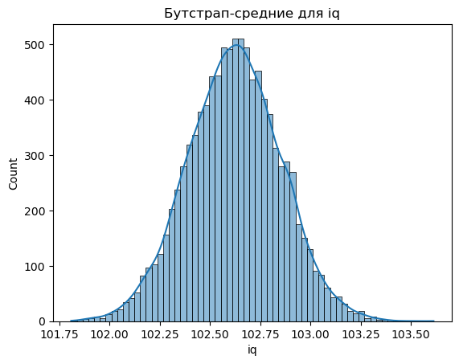

```
95% доверительный интервал для iq: [102.17 103.07]
```

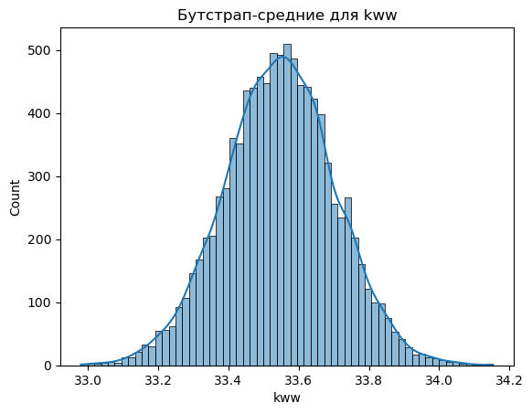

```
95% доверительный интервал для kww: [33.23 33.85]
```

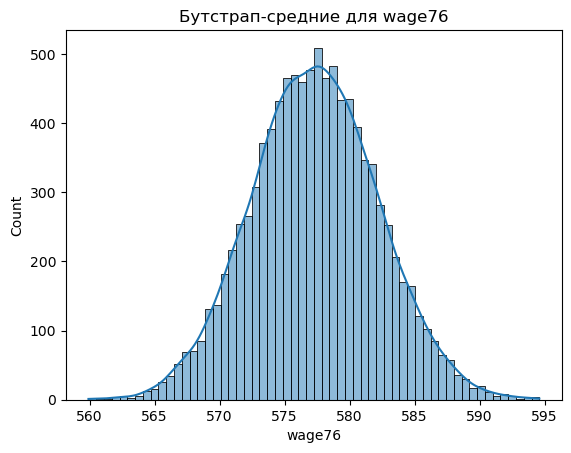

```
95% доверительный интервал для wage76: [567.84 586.9 ]
```

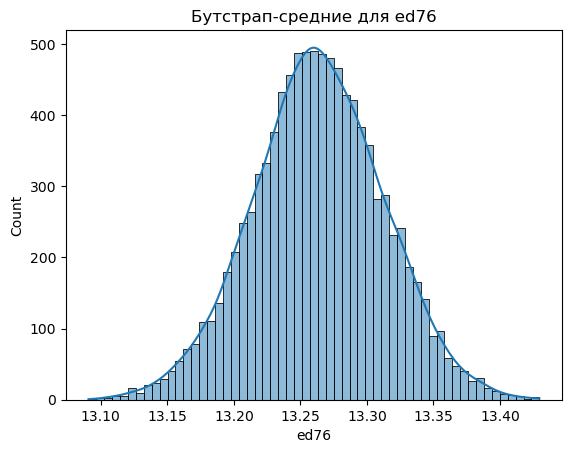

```
95% доверительный интервал для ed76: [13.17 13.36]
```

```python
# Функция бутстрапа для оценки средних

def bootstrap_mean(sample):
    means_list = []
    for _ in range(10000):
        bs_sample = np.random.choice(sample, size=len(sample), replace=True)
        means_list.append(np.mean(bs_sample))
    return means_list

# Список переменных для анализа
variables = ["iq", "kww", "wage76", "ed76"]

bootstrap_results = {}

for var in variables:
    sample = df[var].dropna().values
    means = bootstrap_mean(sample)
    bootstrap_results[var] = means

    # Визуализация распределения бутстрап-оценок средних
    sns.histplot(means, kde=True)
    plt.title(f"Бутстрап-средние для {var}")
    plt.xlabel(var)
    plt.show()

    # Вычисление 95% доверительного интервала
    ci = np.percentile(means, [2.5, 97.5]).round(2)
    print(f"95% доверительный интервал для {var}: {ci}")
```

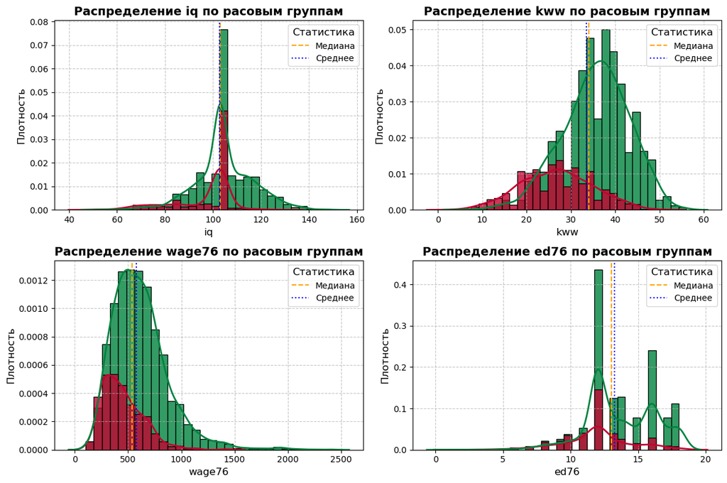

```python
df["race"] = df["black"].map({0: "Европейцы", 1: "Афроамериканцы"})

plt.figure(figsize=(12, 8))

for i, col in enumerate(quantitative_columns, 1):
    plt.subplot(2, 2, i)

    sns.histplot(data=df,
                 x=col,
                 hue="race",
                 # kde=True,
                 bins=30,
                 edgecolor="black",
                 alpha=0.8,
                 stat="density",
                 palette=["#c20430", "#00833f"])

    sns.kdeplot(data=df, x=col, hue="black", palette=["#00833f", "#c20430"], linewidth=2)

    plt.axvline(df[col].median(), color='orange', linestyle='--', label='Медиана')
    plt.axvline(df[col].mean(), color='blue', linestyle=':', label='Среднее')

    plt.xlabel(col, fontsize=12)
    plt.ylabel("Плотность", fontsize=12)
    plt.title(f"Распределение {col} по расовым группам", fontsize=14, fontweight="bold")
    plt.grid(True, linestyle='--', alpha=0.7, linewidth=0.8)
    plt.legend(title="Статистика", fontsize=10, title_fontsize=12)

plt.tight_layout()
```

```python
df = df.drop('race', axis=1)
```

#### 2. Сформулировать и протестировать несколько гипотез касательно разницы сегментов (к примеру, пользователей) по нескольким показателям. Сделать заключение о наличии или отсутствии статистически значимой разницы. К каждой оценке разницы между группами построить точечную и интервальную оценку. Интервальную можно построить методом бутстрэпа.

### Формируем гипотезы!!!

$\alpha = 0.05$

Если $p < \alpha$, то нулевая гипотеза отвергается в пользу альтернативы. Если $p \ge \alpha$, то нулевая гипотеза не отвергается.

Давайте сравним моменты для двух расовых принадлежностей. В качестве рассматриваемых переменных, соответственно, возьмем:

- `wage76` - для тестов с непрерывной переменной;
- `iq` - для тестов с непрерывной переменной;
- `kww` - для тестов с непрерывной переменной;
- `ed76` - для тестов с категориальной переменной.

Попробуем провести оценки через классические тесты, а далее - с помощью бутстрапа. **Ремарка**: хочу найти статистически значимый сдвиг, а не проверять досконально соответствие распределений. Соответственно, давайте прибегнем к **Критерию Уилкоксона-Манна-Уитни**.

#### Двухвыборочная гипотеза о медиане для непрерывного случая (**Критерий Уилкоксона-Манна-Уитни**):

Оценим значимость сдвига распределений.

Конкретизируем гипотезы как:

**Гипотеза 1:**

$H_0$ - $F_X(x) = F_Y(x)$ (разница в медианных значениях IQ респондентов (`iq`) по выборкам клиентов по различным расовым категориям (принадлежностям) НЕ ЯВЛЯЕТСЯ статистически значимой (подробнее: между выборками X и Y нет статистически значимого сдвига, где выборка X - выборка с расовой принадлежностью A, выборка Y - расовой принадлежностью B))

$H_1$ - $F_X(x) = F_Y(x+m), m\neq0$ ((разница в медианных значениях IQ респондентов (`iq`) по выборкам клиентов по различным расовым категориям (принадлежностям) ЯВЛЯЕТСЯ статистически значимой; между выборками X и Y есть статистически значимый сдвиг).

**Гипотеза 2:**

$H_0$ - $F_X(x) = F_Y(x)$ (разница в медианных значениях kWW респондентов (`kww`) по выборкам клиентов по различным расовым категориям (принадлежностям) НЕ ЯВЛЯЕТСЯ статистически значимой (подробнее: между выборками X и Y нет статистически значимого сдвига, где выборка X - выборка с расовой принадлежностью A, выборка Y - расовой принадлежностью B))

$H_1$ - $F_X(x) = F_Y(x+m), m\neq0$ ((разница в медианных значениях KWW респондентов (`kww`) по выборкам клиентов по различным расовым категориям (принадлежностям) ЯВЛЯЕТСЯ статистически значимой; между выборками X и Y есть статистически значимый сдвиг).

**Гипотеза 3:**

$H_0$ - $F_X(x) = F_Y(x)$ (разница в медианных значениях заработных плат респондентов (`wage76`) по выборкам клиентов по различным расовым категориям (принадлежностям) НЕ ЯВЛЯЕТСЯ статистически значимой (подробнее: между выборками X и Y нет статистически значимого сдвига, где выборка X - выборка с расовой принадлежностью A, выборка Y - расовой принадлежностью B))

$H_1$ - $F_X(x) = F_Y(x+m), m\neq0$ ((разница в медианных значениях заработных плат респондентов (`wage76`) по выборкам клиентов по различным расовым категориям (принадлежностям) ЯВЛЯЕТСЯ статистически значимой; между выборками X и Y есть статистически значимый сдвиг).

#### Двухвыборочная гипотеза о распределении для дискретного случая (**Критерий Пирсона**):

**Гипотеза 4:**

***Гипотеза о неизвестном законе распределения:***

$H_0$ - выборки уровня образования (`ed76`) по выборкам респонедтов по различным расовым категориям (принадлежностям) к нам пришли из некоторого распределения $F_0$, идентичного по параметрам.

$H_1$ - выборки уровня образования (`ed76`) по выборкам респонедтов по различным расовым категориям (принадлежностям) к нам НЕ пришли из некоторого распределения $F_0$, идентичного по параметрам.

$$ \begin{aligned} H_0 : X \sim F_0 \\ H_1 : X \nsim F_0 \end{aligned} $$

#### Двухвыборочная гипотеза о медиане для дискретного случая (**Тест Муда**):

**Гипотеза 5:**

Хочу взять Median Non Parametric Hypothesis Test

"This test works when the dependent variable is continuous or discrete count, and the independent variables are discrete with two or more attributes."

$H_0$ - выборки уровня образования (`ed76`) по выборкам респонедтов по различным расовым категориям (принадлежностям) имеют одинаковые медианные значения.

$H_1$ - выборки уровня образования (`ed76`) по выборкам респонедтов по различным расовым категориям (принадлежностям) имеют разные медианные значения.

$H_0: {Med}(X_1 - Y_1) = 0$,

$H_1: {Med}(X_1 - Y_1) \neq 0$

### Перейду к оцениванию

```python
black_sample = df.query('black == 1')
white_sample = df.query('black == 0')
```

**Гипотеза 1:**

$H_0$ - $F_X(x) = F_Y(x)$ (разница в медианных значениях IQ респондентов (`iq`) по выборкам клиентов по различным расовым категориям (принадлежностям) НЕ ЯВЛЯЕТСЯ статистически значимой (подробнее: между выборками X и Y нет статистически значимого сдвига, где выборка X - выборка с расовой принадлежностью A, выборка Y - расовой принадлежностью B))

$H_1$ - $F_X(x) = F_Y(x+m), m\neq0$ ((разница в медианных значениях IQ респондентов (`iq`) по выборкам клиентов по различным расовым категориям (принадлежностям) ЯВЛЯЕТСЯ статистически значимой; между выборками X и Y есть статистически значимый сдвиг).

```python
np.random.seed(42)

def bootstrap_median(sample1, sample2):
    bootstrap_median_diff = []
    for _ in range(10000):
        sample1_resampled = np.random.choice(sample1, size=len(sample1), replace=True)
        sample2_resampled = np.random.choice(sample2, size=len(sample2), replace=True)
        median_diff = np.median(sample1_resampled) - np.median(sample2_resampled)
        bootstrap_median_diff.append(median_diff)
    return bootstrap_median_diff

boot_median1 = bootstrap_median(black_sample['iq'], white_sample['iq'])

# Доверительный интервал
big_ci = np.percentile(boot_median1, q=[2.5, 97.5]).round(4)
print(f"95% доверительный интервал для boot_median1: {big_ci}")

# Манна-Уитни
print(mannwhitneyu(black_sample['iq'], white_sample['iq'], alternative='two-sided'))
```

```
95% доверительный интервал для boot_median1: [0. 0.]
MannwhitneyuResult(statistic=535730.5, pvalue=6.327182405616462e-44)
```

**Гипотеза 2:**

$H_0$ - $F_X(x) = F_Y(x)$ (разница в медианных значениях kWW респондентов (`kww`) по выборкам клиентов по различным расовым категориям (принадлежностям) НЕ ЯВЛЯЕТСЯ статистически значимой (подробнее: между выборками X и Y нет статистически значимого сдвига, где выборка X - выборка с расовой принадлежностью A, выборка Y - расовой принадлежностью B))

$H_1$ - $F_X(x) = F_Y(x+m), m\neq0$ ((разница в медианных значениях KWW респондентов (`kww`) по выборкам клиентов по различным расовым категориям (принадлежностям) ЯВЛЯЕТСЯ статистически значимой; между выборками X и Y есть статистически значимый сдвиг).

```python
np.random.seed(42)

def bootstrap_median(sample1, sample2):
    bootstrap_median_diff = []
    for _ in range(10000):
        sample1_resampled = np.random.choice(sample1, size=len(sample1), replace=True)
        sample2_resampled = np.random.choice(sample2, size=len(sample2), replace=True)
        median_diff = np.median(sample1_resampled) - np.median(sample2_resampled)
        bootstrap_median_diff.append(median_diff)
    return bootstrap_median_diff

boot_median2 = bootstrap_median(black_sample['kww'], white_sample['kww'])

# Доверительный интервал
big_ci = np.percentile(boot_median2, q=[2.5, 97.5]).round(2)
print(f"95% доверительный интервал для boot_median2: {big_ci}")

# Манна-Уитни
print(mannwhitneyu(black_sample['kww'], white_sample['kww'], alternative='two-sided'))
```

```
95% доверительный интервал для boot_median2: [-10.  -9.]
MannwhitneyuResult(statistic=344782.0, pvalue=2.758589753262729e-118)
```

**Гипотеза 3:**

$H_0$ - $F_X(x) = F_Y(x)$ (разница в медианных значениях заработных плат респондентов (`wage76`) по выборкам клиентов по различным расовым категориям (принадлежностям) НЕ ЯВЛЯЕТСЯ статистически значимой (подробнее: между выборками X и Y нет статистически значимого сдвига, где выборка X - выборка с расовой принадлежностью A, выборка Y - расовой принадлежностью B))

$H_1$ - $F_X(x) = F_Y(x+m), m\neq0$ ((разница в медианных значениях заработных плат респондентов (`wage76`) по выборкам клиентов по различным расовым категориям (принадлежностям) ЯВЛЯЕТСЯ статистически значимой; между выборками X и Y есть статистически значимый сдвиг).

```
95% доверительный интервал для boot_median3: [-189. -147.]
MannwhitneyuResult(statistic=479432.0, pvalue=1.1201631171366122e-60)
```

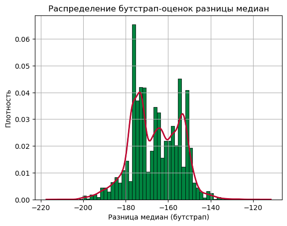

```python
np.random.seed(42)

def bootstrap_median(sample1, sample2):
    bootstrap_median_diff = []
    for _ in range(10000):
        sample1_resampled = np.random.choice(sample1, size=len(sample1), replace=True)
        sample2_resampled = np.random.choice(sample2, size=len(sample2), replace=True)
        median_diff = np.median(sample1_resampled) - np.median(sample2_resampled)
        bootstrap_median_diff.append(median_diff)
    return bootstrap_median_diff

boot_median3 = bootstrap_median(black_sample['wage76'], white_sample['wage76'])

# Доверительный интервал
big_ci = np.percentile(boot_median3, q=[2.5, 97.5]).round(2)
print(f"95% доверительный интервал для boot_median3: {big_ci}")

# Манна-Уитни
print(mannwhitneyu(black_sample['wage76'], white_sample['wage76'], alternative='two-sided'))

sns.histplot(boot_median3,
             kde=True,
             edgecolor="black",
             alpha=1,
             shrink=1,
             stat="density",
             color='#00833f'
            )


sns.kdeplot(data=boot_median3, color="#c20430", linewidth=2)

plt.xlabel("Разница медиан (бутстрап)")
plt.ylabel("Плотность")
plt.title("Распределение бутстрап-оценок разницы медиан")
plt.grid(True)

plt.show()
```

#### Двухвыборочная гипотеза о распределении для дискретного случая (**Критерий Пирсона**):

**Гипотеза 4:**

***Гипотеза о неизвестном законе распределения:***

$H_0$ - выборки уровня образования (`ed76`) по выборкам респонедтов по различным расовым категориям (принадлежностям) к нам пришли из некоторого распределения $F_0$, идентичного по параметрам.

$H_1$ - выборки уровня образования (`ed76`) по выборкам респонедтов по различным расовым категориям (принадлежностям) к нам НЕ пришли из некоторого распределения $F_0$, идентичного по параметрам.

$$ \begin{aligned} H_0 : X \sim F_0 \\ H_1 : X \nsim F_0 \end{aligned} $$

#### Двухвыборочная гипотеза о медиане для дискретного случая (**Тест Муда**):

**Гипотеза 5:**

Хочу взять Median Non Parametric Hypothesis Test

"This test works when the dependent variable is continuous or discrete count, and the independent variables are discrete with two or more attributes."

$H_0$ - выборки уровня образования (`ed76`) по выборкам респонедтов по различным расовым категориям (принадлежностям) имеют одинаковые медианные значения.

$H_1$ - выборки уровня образования (`ed76`) по выборкам респонедтов по различным расовым категориям (принадлежностям) имеют разные медианные значения.

$H_0: {Med}(X_1 - Y_1) = 0$,

$H_1: {Med}(X_1 - Y_1) \neq 0$

```python
# Частоты для каждой категории

black_sample_ed = black_sample['ed76']
white_sample_ed = white_sample['ed76']

black_sample_ed_counts = black_sample_ed.value_counts().sort_index()
white_sample_counts = white_sample_ed.value_counts().sort_index()

# Формируем таблицу сопряженности
contingency_table = pd.DataFrame({
    'Black': black_sample_ed_counts,
    'White': white_sample_counts
}).fillna(0)
```

```python
np.random.seed(42)

def bootstrap_median(sample1, sample2):
    bootstrap_median_diff = []
    for _ in range(10000):
        sample1_resampled = np.random.choice(sample1, size=len(sample1), replace=True)
        sample2_resampled = np.random.choice(sample2, size=len(sample2), replace=True)
        median_diff = np.median(sample1_resampled) - np.median(sample2_resampled)
        bootstrap_median_diff.append(median_diff)
    return bootstrap_median_diff


boot_median4 = bootstrap_median(black_sample['ed76'], white_sample['ed76'])

big_ci = np.percentile(boot_median4, q=[2.5, 97.5]).round(2)
print(f"95% доверительный интервал для boot_median4 {big_ci}")


# Тест Пирсона
print(stats.chi2_contingency(contingency_table.T))

# Применяем тест Муда
print(stats.median_test(black_sample['ed76'], white_sample['ed76']))
```

```
95% доверительный интервал для boot_median4 [-1. -1.]
Chi2ContingencyResult(statistic=256.4120720791628, pvalue=1.0207168481343285e-44, dof=17, expected_freq=array([[2.33554817e-01, 4.67109635e-01, 7.00664452e-01, 7.00664452e-01,
        2.33554817e+00, 3.73687708e+00, 6.77308970e+00, 1.58817276e+01,
        1.89179402e+01, 2.91943522e+01, 3.71352159e+01, 2.31686379e+02,
        6.56289037e+01, 6.14249169e+01, 3.73687708e+01, 1.07201661e+02,
        3.52667774e+01, 4.83458472e+01],
       [7.66445183e-01, 1.53289037e+00, 2.29933555e+00, 2.29933555e+00,
        7.66445183e+00, 1.22631229e+01, 2.22269103e+01, 5.21182724e+01,
        6.20820598e+01, 9.58056478e+01, 1.21864784e+02, 7.60313621e+02,
        2.15371096e+02, 2.01575083e+02, 1.22631229e+02, 3.51798339e+02,
        1.15733223e+02, 1.58654153e+02]]))
MedianTestResult(statistic=137.7878155862318, pvalue=8.109498443437887e-32, median=13.0, table=array([[ 155, 1085],
       [ 548, 1222]], dtype=int64))
```

### Точный доверительный интервал для среднего значения (на базе t-критического значения)

$$ \bar x \pm t_{1 - \frac{\alpha}{2}} \cdot \sqrt{\frac{\hat s^2}{n}}. $$

```python
def t_confidence_interval_mean_diff(sample1, sample2, alpha=0.05):
    n1, n2 = len(sample1), len(sample2)
    mean1, mean2 = np.mean(sample1), np.mean(sample2)
    var1, var2 = np.var(sample1, ddof=1), np.var(sample2, ddof=1)
    se_diff = np.sqrt(var1 / n1 + var2 / n2)
    df = ((var1 / n1 + var2 / n2) ** 2) / ((var1**2 / (n1**2 * (n1 - 1))) + (var2**2 / (n2**2 * (n2 - 1))))
    t_crit = stats.t.ppf(1 - alpha / 2, df)

    # Доверительный интервал
    diff_mean = mean1 - mean2
    ci_low = diff_mean - t_crit * se_diff
    ci_high = diff_mean + t_crit * se_diff

    return ci_low, ci_high

ci_low, ci_high = t_confidence_interval_mean_diff(black_sample['iq'], white_sample['iq'])

print(f"95% точный доверительный интервал для разницы средних: [{ci_low:.4f}, {ci_high:.4f}]")

ci_low2, ci_high2 = t_confidence_interval_mean_diff(black_sample['kww'], white_sample['kww'])

print(f"95% точный доверительный интервал для разницы средних: [{ci_low2:.4f}, {ci_high2:.4f}]")


ci_low3, ci_high3 = t_confidence_interval_mean_diff(black_sample['wage76'], white_sample['wage76'])

print(f"95% точный доверительный интервал для разницы средних: [{ci_low3:.4f}, {ci_high3:.4f}]")


ci_low4, ci_high4 = t_confidence_interval_mean_diff(black_sample['ed76'], white_sample['ed76'])

print(f"95% точный доверительный интервал для разницы средних: [{ci_low4:.4f}, {ci_high4:.4f}]")
```

```
95% точный доверительный интервал для разницы средних: [-9.6366, -7.5166]
95% точный доверительный интервал для разницы средних: [-9.5084, -8.1643]
95% точный доверительный интервал для разницы средних: [-186.3525, -150.4985]
95% точный доверительный интервал для разницы средних: [-1.9249, -1.4834]
```

## Сводная таблица

### Результаты статистических тестов для расовых групп

| **Показатель** | **Тест** | **Статистика** | **p-значение** | **$H_0$ принимается** |
| --- | --- | --- | --- | --- |
| **IQ** | Mann-Whitney U | 535730.5 | 6.33e-44 | Нет |
| **KWW** | Mann-Whitney U | 344782.0 | 2.76e-118 | Нет |
| **Wage76** | Mann-Whitney U | 479432.0 | 1.12e-60 | Нет |
| **Ed76** | Критерий Пирсона | 256.41 (dof=17) | 1.02e-44 | Нет |
| **Ed76** | Тест Муда | 137.79 | 8.11e-32 | Нет |

### Результаты бутстрап-интервалов

| **Показатель** | **95% доверительный интервал для разницы медиан** | **$H_0$ принимается** |
| --- | --- | --- |
| **IQ** | [0.0, 0.0] | Да (разницы не было изначально) |
| **KWW** | [-10.0, -9.0] | Нет |
| **Wage76** | [-189.0, -147.0] | Нет |
| **Ed76** | [-1.0, -1.0] | Нет |

### Точные 95% доверительные интервалы для разницы средних

| **Показатель** | **95% доверительный интервал** | **$H_0$ (новая; такая же, только о средних) принимается** |
| --- | --- | --- |
| **IQ** | [-9.6366, -7.5166] | Нет |
| **KWW** | [-9.5084, -8.1643] | Нет |
| **Wage76** | [-186.3525, -150.4985] | Нет |
| **Ed76** | [-1.9249, -1.4834] | Нет |

### Выводы:

#### 3. Если какая-то группа хуже другой, то сформировать ряд продуктовых гипотез, почему такое могло произойти и предложить идеи, какие эксперименты можно было провести на отстающей группе для повышения показателей.

- Расовое неравенство на институциональном уровне являлось краеугольным камнем социально и экономического разрыва белого и чёрного населения;
- Скорее всего, социальный институт предвзятости был крайне развит и не давал чернокожему населению реализоваться как на образовательном поприще, так и в карьерном, что и выражалось в соответствующей разнице;
- Можно попробовать провести более сбалансированные (робастные) эвристики для оценки неравноценных по размеру выборок классов.

## Регрессионный анализ

1. Оценить модель линейной регрессии методом МНК, подготовить репорт модели и проинтерпретировать оценки коэффициентов.
2. Провести тесты на гетероскедастичность, мультиколлинеарность (как визуальные, так и численные), дать комментарии по произведенным тестам. В случае нарушения предпосылок Гаусса-Маркова – принять соответствующие корректирующие модель действия, после чего повторить пункт 1.
3. В ходе анализа протестируйте как минимум 2 спецификации моделей. Финальная спецификация модели может включать не все факторы и не все наблюдения из исходной выборки. Продемонстрируйте на примере финальной и одной из промежуточных моделей, по каким критериям и метрикам был произведен выбор в пользу финальной спецификации. Дайте трактовку значениям этих критериев и метрик.

#### Предпосылки Гаусса Маркова

**Предпосылка ГМ-1. Линейная взаимосвязь**

В модели генеральной совокупности зависимая случайная величина $y$ и независимая случайная величина $x$ имеют линейную взаимосвязь: $$ y = \beta_0 + \beta_1 x_1 + \dots + \beta_k x_k + \varepsilon $$ **Предпосылка ГМ-2. Случайная выборка**

Выборки случайных величин $y$ и $x$, на основании которых строится модель, являются репрезентативными случайными выборками своих генеральных совокупностей (Independent and Identically Distributed, i.i.d.).

**Предпосылка ГМ-3. Вариативность регрессоров**

**Парная регрессия:**

Выборка значений случайной величины $x$, а именно $\{x_i, i =1,\dots,n\}$, имеет вариативность.

**Множественная регрессия:**

Отсутствие полной коллинеарности в регрессорах. Выборка значений случайных величин $x_1, \dots, x_k$, а именно $\{x_{i1},\dots,x_{ik}, i =1,\dots,n\}$, имеет вариативность, а также среди регрессоров отсутствует строгая линейная зависимость.

**Предпосылка ГМ-4. Независимость регрессоров и ошибки модели**

Условное математическое ожидание ошибки модели $\varepsilon$ по регрессорам $x_i$ равно 0:

$$ E[\varepsilon \mid x_1, x_2, \dots, x_k] = 0 $$

**Предпосылка ГМ-5. Гомоскедастичность**

Стандартное отклонение ошибки модели $\varepsilon$ постоянно и не зависит от регрессоров $x_i$:

$$ \text{Var}(\varepsilon \mid x_1, x_2, \dots, x_k) = \sigma^2 $$

**Предпосылка ГМ-6: Нормальность ошибки**

В генеральной совокупности случайная ошибка $\varepsilon$ имеет нормальное распределение с параметрами: $$ \varepsilon \sim N(0, \sigma^2) $$

**Что мы имеем теперь?**

Предпосылка №6 не является частью предпосылок Гаусса-Маркова, это дополнительное ограничение, которое мы вводим из-за следующих причин:

- Мы хотим иметь какое-то знание о распределении оценок МНК.
- Ошибка модели аккумулирует в себе эффекты от всех прочих факторов на $y$, которые не включены в уравнение.

## Сразу разберемся с мультиколлинеарностью

**Предпосылка ГМ-3. Вариативность регрессоров**

**Множественная регрессия:**

Отсутствие полной коллинеарности в регрессорах. Выборка значений случайных величин $x_1, \dots, x_k$, а именно $\{x_{i1},\dots,x_{ik}, i =1,\dots,n\}$, имеет вариативность, а также среди регрессоров отсутствует строгая линейная зависимость.

```python
X = df[['nearc2', 'nearc4', 'nearc4a', 'nearc4b', 'ed76', 'age76', 'daded',
        'momed', 'momdad14', 'sinmom14', 'step14', 'reg661', 'reg662', 'reg663',
        'reg664', 'reg665', 'reg666', 'reg667', 'reg668', 'reg669', 'south66',
        'famed', 'black', 'smsa76r', 'reg76r',
        'smsa66r', 'enroll76', 'kww', 'iq', 'marsta76', 'libcrd14']]
```

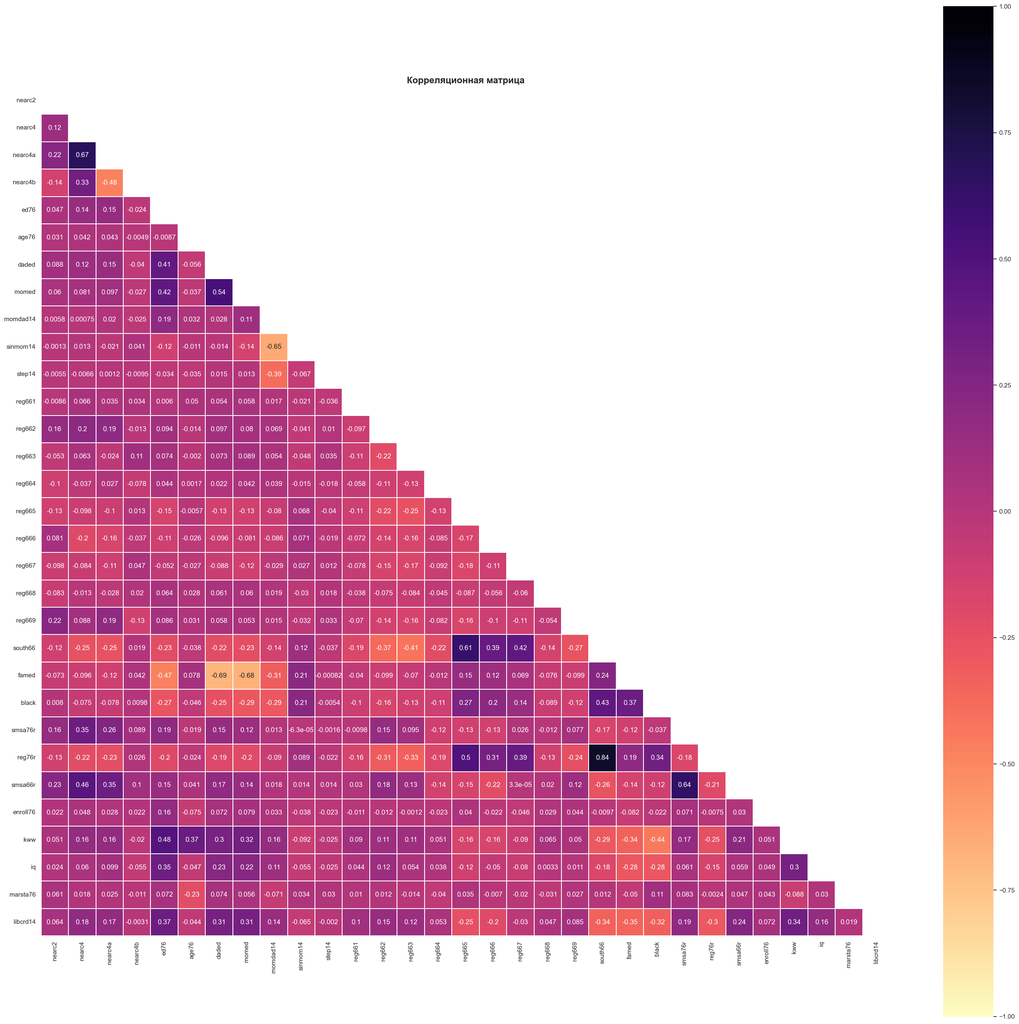

```python
corr_matrix = X.corr()
sns.set(style="white")

plt.figure(figsize=(27, 25))

mask = np.triu(np.ones_like(corr_matrix, dtype=bool))

sns.heatmap(corr_matrix,
            annot=True,
            cmap='magma_r',
            # fmt='.2f',
            linewidths=0.3,
            mask=mask,
            vmin=-1,
            vmax=1,
            linecolor='white',
            square=True)
plt.title('Корреляционная матрица', fontsize=16, fontweight='bold')

plt.tight_layout()
```

### Выводы по корреляционной матрице

Скоррелированы south66 и reg76r (0.84). Очевидно, в целом, так как с большой вероятностью люди не переезжают на север. Условно, как если бы ты родился в Сибири, вероятность того, что ты переехал бы в Москву, не является настолько высокой, чтобы так поступал каждый потенциальный студент, а не условные 5% из массы.

Однако, есть подходы для численной оценки уровня мультиколлинеарности. Некоторые из них:

- **Variance Inflation Factor (VIF)** — наиболее часто используемая метрика. Это частная мера зависимости дисперсии оценки коэффициента $\beta_j$ от корреляции рассматриваемого регрессора со всеми прочими регрессорами:

$$\large VIF_j = \frac{1}{1 - R^2_j} $$

Откуда получаем, что дисперсию коэффициента можно выразить как: $$ \text{Var}(\beta_j) = \frac{\sum_{i=1}^{n} r^2_{ij} \varepsilon^2_i}{\sum_{i=1}^{n} (x_{ij} - \bar{x}_j)^2} $$ **Бенчмарк:**

Если $VIF_j > 10$ (что соответствует $R^2_j > 0.9$), это считается критичным значением, при котором стоит задуматься о работе с факторами.

### Проведём VIF

```python
# Еще одна проверка на мультиколлинеарность
# https://corporatefinanceinstitute.com/resources/data-science/variance-inflation-factor-vif/
#:~:text=Generally%2C%20a%20VIF%20above%204,that%20needs%20to%20be%20corrected.
# https://education.yandex.ru/handbook/data-analysis/article/pandan-linejnaya-regressiya-v-python

# from statsmodels.stats.outliers_influence import variance_inflation_factor

# Выбор независимых переменных
X = df[['nearc2', 'nearc4', 'nearc4a', 'nearc4b', 'ed76', 'age76', 'daded',
        'momed', 'momdad14', 'sinmom14', 'step14', 'reg661', 'reg662', 'reg663',
        'reg664', 'reg665', 'reg666', 'reg667', 'reg668', 'reg669', 'south66',
        'famed', 'black', 'smsa76r', 'reg76r',
        'smsa66r', 'enroll76', 'kww', 'iq', 'marsta76', 'libcrd14']]



# Создание DataFrame для хранения результатов VIF
vif_data = pd.DataFrame()
vif_data["feature"] = X.columns

# Вычисление VIF для каждого признака
vif_data["VIF"] = [variance_inflation_factor(X.values, i)
                          for i in range(len(X.columns))]

print(vif_data)

for i in range(len(vif_data)):
    vif_value = vif_data.loc[i, 'VIF']
    feature = vif_data.loc[i, 'feature']

    if vif_value > 10:
        print(f"Переменная {feature} имеет VIF = {vif_value:.2f} (сильная мультиколлинеарность, требует коррекции)")
    elif vif_value > 4:
        print(f"Переменная {feature} имеет VIF = {vif_value:.2f} (возможная мультиколлинеарность, требуется проверка)")
```

```
     feature        VIF
0     nearc2   1.212800
1     nearc4        inf
2    nearc4a        inf
3    nearc4b        inf
4       ed76   1.737553
5      age76   1.361644
6      daded   2.194709
7      momed   2.064864
8   momdad14   3.216404
9   sinmom14   2.278696
10    step14   1.598390
11    reg661  16.264094
12    reg662  53.724629
13    reg663  64.682291
14    reg664  21.910526
15    reg665        inf
16    reg666        inf
17    reg667        inf
18    reg668  10.053419
19    reg669  29.989013
20   south66        inf
21     famed   3.348922
22     black   1.655675
23   smsa76r   1.815610
24    reg76r   3.553118
25   smsa66r   2.119333
26  enroll76   1.048390
27       kww   2.004511
28        iq   1.248918
29  marsta76   1.095793
30  libcrd14   1.408519
Переменная nearc4 имеет VIF = inf (сильная мультиколлинеарность, требует коррекции)
Переменная nearc4a имеет VIF = inf (сильная мультиколлинеарность, требует коррекции)
Переменная nearc4b имеет VIF = inf (сильная мультиколлинеарность, требует коррекции)
Переменная reg661 имеет VIF = 16.26 (сильная мультиколлинеарность, требует коррекции)
Переменная reg662 имеет VIF = 53.72 (сильная мультиколлинеарность, требует коррекции)
Переменная reg663 имеет VIF = 64.68 (сильная мультиколлинеарность, требует коррекции)
Переменная reg664 имеет VIF = 21.91 (сильная мультиколлинеарность, требует коррекции)
Переменная reg665 имеет VIF = inf (сильная мультиколлинеарность, требует коррекции)
Переменная reg666 имеет VIF = inf (сильная мультиколлинеарность, требует коррекции)
Переменная reg667 имеет VIF = inf (сильная мультиколлинеарность, требует коррекции)
Переменная reg668 имеет VIF = 10.05 (сильная мультиколлинеарность, требует коррекции)
Переменная reg669 имеет VIF = 29.99 (сильная мультиколлинеарность, требует коррекции)
Переменная south66 имеет VIF = inf (сильная мультиколлинеарность, требует коррекции)
```

#### Еще проверки

```python
singular_values = np.linalg.svd(X, compute_uv=False)
print(f"Сингулярные числа:\n{singular_values}")
print()
rank = np.linalg.matrix_rank(X)
print(f"Ранг матрицы:\n{rank},\nЧисло переменных:\n{X.shape[1]}")
```

```
Сингулярные числа:
[6.26481240e+03 4.46309554e+02 2.61111219e+02 2.06077632e+02
 1.22264166e+02 1.16013439e+02 1.07988529e+02 8.83540868e+01
 4.51145679e+01 3.53551786e+01 2.94853519e+01 2.66634469e+01
 2.43635498e+01 2.30028164e+01 2.26730763e+01 2.14077888e+01
 2.08711302e+01 1.86190316e+01 1.74245144e+01 1.66264245e+01
 1.54850547e+01 1.46430300e+01 1.40496280e+01 1.29008783e+01
 1.24282583e+01 1.11168745e+01 9.48279028e+00 7.26741481e+00
 1.16789349e+00 7.65672666e-14 3.89455447e-14]

Ранг матрицы:
29,
Число переменных:
31
```

Ситуация не очень...

### Выводы:

Предполагаю, что исследователи не убрали линейные комбинации по регионам (**ловушка дамми-переменных**). Сложно сказать, почему это не видно на корреляционной матрице. В любом случае, достаточно убрать один из рассматриваемых признаков. Еще стоит отметить, что часть переменных подразумевалась попросту как инструменты, поэтому и идея в их оценивании была изначально другой.

Давайте снова упрощу задачу: рассмотрю наиболее значимые регрессоры в нашей задаче. Потенциально "опасные" для нас переменные я исключу.

```python
# df = df.drop('nearc4b', axis=1)
# df = df.drop('reg669', axis=1)
# df = df.drop('reg76r', axis=1)
# df = df.drop('famed', axis=1)
# df = df.drop('smsa76r', axis=1)
# df = df.drop('south66', axis=1)
# # near4 и nearc4a - 4-летний колледж и 4-летний публичный колледж. Но есть переменная для private колледжа.
# # Зачем нам по факту одна и та же переменная в модели?
# df = df.drop('nearc4a', axis=1)
```

```python
# Выбор независимых переменных
X_new = df[['nearc2', 'nearc4', 'ed76', 'age76', 'daded',
        'momed', 'momdad14', 'sinmom14', 'step14', 'reg661', 'reg662', 'reg663',
        'reg664', 'reg665', 'reg666', 'reg667', 'reg668',
        'black',
        'smsa66r', 'enroll76', 'kww', 'iq', 'marsta76', 'libcrd14']]



# Создание DataFrame для хранения результатов VIF
vif_data = pd.DataFrame()
vif_data["feature"] = X_new.columns

# Вычисление VIF для каждого признака
vif_data["VIF"] = [variance_inflation_factor(X_new.values, i)
                          for i in range(len(X_new.columns))]

print(vif_data)

for i in range(len(vif_data)):
    vif_value = vif_data.loc[i, 'VIF']
    feature = vif_data.loc[i, 'feature']

    if vif_value > 10:
        print(f"Переменная {feature} имеет VIF = {vif_value:.2f} (сильная мультиколлинеарность, требует коррекции)")
    elif vif_value > 4:
        print(f"Переменная {feature} имеет VIF = {vif_value:.2f} (возможная мультиколлинеарность, требуется проверка)")
```

```
     feature        VIF
0     nearc2   2.117343
1     nearc4   4.211341
2       ed76  42.696670
3      age76  56.820849
4      daded  16.247983
5      momed  20.530696
6   momdad14  12.515187
7   sinmom14   2.393801
8     step14   1.540262
9     reg661   1.543068
10    reg662   2.756575
11    reg663   3.205340
12    reg664   1.788225
13    reg665   3.672552
14    reg666   2.289840
15    reg667   2.347577
16    reg668   1.343876
17     black   2.074813
18   smsa66r   4.202749
19  enroll76   1.151454
20       kww  31.339067
21        iq  58.782611
22  marsta76   2.343881
23  libcrd14   4.267138
Переменная nearc4 имеет VIF = 4.21 (возможная мультиколлинеарность, требуется проверка)
Переменная ed76 имеет VIF = 42.70 (сильная мультиколлинеарность, требует коррекции)
Переменная age76 имеет VIF = 56.82 (сильная мультиколлинеарность, требует коррекции)
Переменная daded имеет VIF = 16.25 (сильная мультиколлинеарность, требует коррекции)
Переменная momed имеет VIF = 20.53 (сильная мультиколлинеарность, требует коррекции)
Переменная momdad14 имеет VIF = 12.52 (сильная мультиколлинеарность, требует коррекции)
Переменная smsa66r имеет VIF = 4.20 (возможная мультиколлинеарность, требуется проверка)
Переменная kww имеет VIF = 31.34 (сильная мультиколлинеарность, требует коррекции)
Переменная iq имеет VIF = 58.78 (сильная мультиколлинеарность, требует коррекции)
Переменная libcrd14 имеет VIF = 4.27 (возможная мультиколлинеарность, требуется проверка)
```

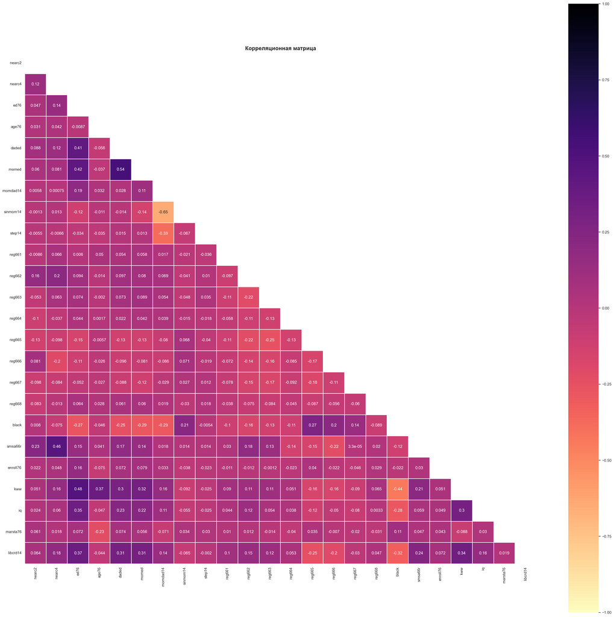

```python
corr_matrix = X_new.corr()
sns.set(style="white")

plt.figure(figsize=(27, 25))

mask = np.triu(np.ones_like(corr_matrix, dtype=bool))

sns.heatmap(corr_matrix,
            annot=True,
            cmap='magma_r',
            # fmt='.2f',
            linewidths=0.3,
            mask=mask,
            vmin=-1,
            vmax=1,
            linecolor='white',
            square=True)
plt.title('Корреляционная матрица', fontsize=16, fontweight='bold')

plt.tight_layout()
```

### Выводы:

Я считаю, что высокий VIF и корреляции дают показатели интеллектуальных тестов. Они не просто связаны между собой (ты хорошо сдаешь IQ, значит, и когнитивное тестирование), так и потенциально с регрессорами образования. Оставлю пока всё, как есть, так как линейной зависимости я не наблюдаю.

## Baseline Линейная Регрессия

Сразу оговорюсь, что сразу буду использовать робастные стандартные ошибки (эконометрический стандарт в эмпирических исследованиях). Поэтому, проверки на гетероскедастичность, скорее, "на всякий случай".

```python
X = X_new
Y = df['wage76']
Y_log = df['lwage76']
```

#### LR без робастных ошибок

```python
X = sm.add_constant(X)
model_baseline = sm.OLS(Y, X).fit()
print(model_baseline.summary())
```

```
                            OLS Regression Results
==============================================================================
Dep. Variable:                 wage76   R-squared:                       0.289
Model:                            OLS   Adj. R-squared:                  0.283
Method:                 Least Squares   F-statistic:                     50.60
Date:                Mon, 17 Mar 2025   Prob (F-statistic):          1.50e-200
Time:                        21:33:05   Log-Likelihood:                -20529.
No. Observations:                3010   AIC:                         4.111e+04
Df Residuals:                    2985   BIC:                         4.126e+04
Df Model:                          24
Covariance Type:            nonrobust
==============================================================================
                 coef    std err          t      P>|t|      [0.025      0.975]
------------------------------------------------------------------------------
const       -287.7864     60.626     -4.747      0.000    -406.660    -168.913
nearc2        28.9828      8.903      3.255      0.001      11.525      46.440
nearc4        16.0666     10.096      1.591      0.112      -3.730      35.863
ed76          17.1306      1.983      8.640      0.000      13.243      21.018
age76         17.2296      1.504     11.458      0.000      14.281      20.178
daded          0.1503      1.559      0.096      0.923      -2.906       3.207
momed          2.4674      1.722      1.433      0.152      -0.909       5.843
momdad14       1.3994     16.593      0.084      0.933     -31.136      33.935
sinmom14      -8.4506     20.136     -0.420      0.675     -47.933      31.032
step14       -38.0293     25.987     -1.463      0.143     -88.983      12.924
reg661       -97.1930     23.569     -4.124      0.000    -143.406     -50.980
reg662       -29.4434     17.052     -1.727      0.084     -62.878       3.991
reg663        -7.9208     16.790     -0.472      0.637     -40.842      25.000
reg664       -69.2639     21.776     -3.181      0.001    -111.961     -26.567
reg665       -70.7732     17.595     -4.022      0.000    -105.272     -36.274
reg666       -71.6409     20.294     -3.530      0.000    -111.433     -31.849
reg667       -78.4680     19.287     -4.069      0.000    -116.284     -40.652
reg668      -121.3457     28.208     -4.302      0.000    -176.656     -66.036
black        -50.0632     12.248     -4.087      0.000     -74.079     -26.047
smsa66r       42.4921     10.326      4.115      0.000      22.246      62.738
enroll76     -73.8480     14.328     -5.154      0.000    -101.942     -45.754
kww            4.2234      0.672      6.289      0.000       2.907       5.540
iq             0.2861      0.354      0.808      0.419      -0.408       0.981
marsta76     -16.3189      2.053     -7.949      0.000     -20.344     -12.294
libcrd14      14.3382     10.243      1.400      0.162      -5.745      34.422
==============================================================================
Omnibus:                      901.238   Durbin-Watson:                   1.898
Prob(Omnibus):                  0.000   Jarque-Bera (JB):             4190.831
Skew:                           1.368   Prob(JB):                         0.00
Kurtosis:                       8.092   Cond. No.                     1.77e+03
==============================================================================

Notes:
[1] Standard Errors assume that the covariance matrix of the errors is correctly specified.
[2] The condition number is large, 1.77e+03. This might indicate that there are
strong multicollinearity or other numerical problems.
```

```python
X = sm.add_constant(X)
model_baseline = sm.OLS(Y, X).fit()

het_data = pd.DataFrame()
het_data['Y_true'] = Y
het_data['Y_pred'] = model_baseline.predict(X)
residuals = model_baseline.resid
het_data['Residuals'] = residuals
het_data.head(2)
```

|  | Y_true | Y_pred | Residuals |
| --- | --- | --- | --- |
| 0 | 548.0 | 331.702187 | 216.297813 |
| 1 | 481.0 | 523.060816 | -42.060816 |

[figure not shown]

```python
# plt.figure(figsize=(6, 5))
plt.figure(figsize=(8, 6))


sns.set_style("whitegrid")
palette = sns.color_palette("coolwarm", as_cmap=True)


sns.scatterplot(data=het_data,
                x='Y_pred',
                y='Residuals',
                hue='Residuals',
                palette=palette,
                size="Y_pred",
                sizes=(20, 100),
                s=80,
                alpha=0.5,
                edgecolor="black",
                linewidth=0.5
                # marker='o'
)

sns.regplot(data=het_data,
            x='Y_pred',
            y='Residuals',
            scatter=False,
            # order=2,
            # lowess=True,
            color='red',
            line_kws={'linewidth': 2, 'linestyle': '--'}
           )

# sns.stripplot(data=df, x='employ', y='income', jitter=True, alpha=0.3)

plt.title('Предсказанные значения дохода VS остатки', fontsize=14, fontweight='bold')
plt.xlabel('Реальные значения дохода', fontsize=14)
plt.ylabel('Остатки', fontsize=14)
# plt.xticks(fontsize=10)
# plt.yticks(fontsize=10)


plt.grid(True, linestyle='-.', linewidth=0.7, alpha=0.7)
# plt.grid(True, which='both', linestyle='--', alpha=0.5)
plt.legend(title="Доход", fontsize=10, title_fontsize=12, frameon=True, edgecolor="black", facecolor="white")

plt.tight_layout()
```

```python
# Получаем остатки модели - забыл, что их можно так еще взять
residuals = model_baseline.resid

# Выполняем тест Пагана-Бройша
test_result = sms.het_breuschpagan(residuals, X)

# Результаты теста
labels = ['LM Statistic', 'LM p-value', 'F-Statistic', 'F p-value']
test_result_df = pd.DataFrame(test_result, index=labels, columns=['Test Statistic'])

print(test_result_df)
```

```
              Test Statistic
LM Statistic    1.306988e+02
LM p-value      1.159086e-16
F-Statistic     5.645698e+00
F p-value       4.433753e-17
```

### Выводы:

- Заметная явная гетероскедастичность по графику;
- Тест Пагана-Бройша подтверждает данное визуальное предположение;
- Теперь используем робастные стандартные ошибки в версии HC3

```python
X = sm.add_constant(X)
model_baseline_robust = sm.OLS(Y, X).fit(cov_type='HC3')
print(model_baseline_robust.summary())
```

```
                            OLS Regression Results
==============================================================================
Dep. Variable:                 wage76   R-squared:                       0.289
Model:                            OLS   Adj. R-squared:                  0.283
Method:                 Least Squares   F-statistic:                     44.69
Date:                Mon, 17 Mar 2025   Prob (F-statistic):          1.04e-178
Time:                        21:33:06   Log-Likelihood:                -20529.
No. Observations:                3010   AIC:                         4.111e+04
Df Residuals:                    2985   BIC:                         4.126e+04
Df Model:                          24
Covariance Type:                  HC3
==============================================================================
                 coef    std err          z      P>|z|      [0.025      0.975]
------------------------------------------------------------------------------
const       -287.7864     69.629     -4.133      0.000    -424.256    -151.317
nearc2        28.9828      8.962      3.234      0.001      11.417      46.549
nearc4        16.0666      9.398      1.710      0.087      -2.353      34.487
ed76          17.1306      2.030      8.440      0.000      13.152      21.109
age76         17.2296      1.605     10.733      0.000      14.083      20.376
daded          0.1503      1.525      0.099      0.921      -2.838       3.139
momed          2.4674      1.764      1.399      0.162      -0.990       5.925
momdad14       1.3994     13.902      0.101      0.920     -25.847      28.646
sinmom14      -8.4506     17.613     -0.480      0.631     -42.972      26.070
step14       -38.0293     20.662     -1.841      0.066     -78.527       2.468
reg661       -97.1930     24.346     -3.992      0.000    -144.910     -49.476
reg662       -29.4434     20.334     -1.448      0.148     -69.298      10.411
reg663        -7.9208     19.523     -0.406      0.685     -46.185      30.344
reg664       -69.2639     23.207     -2.985      0.003    -114.749     -23.778
reg665       -70.7732     20.215     -3.501      0.000    -110.395     -31.152
reg666       -71.6409     21.001     -3.411      0.001    -112.803     -30.479
reg667       -78.4680     21.809     -3.598      0.000    -121.212     -35.724
reg668      -121.3457     27.091     -4.479      0.000    -174.444     -68.248
black        -50.0632     11.415     -4.386      0.000     -72.437     -27.689
smsa66r       42.4921      9.868      4.306      0.000      23.152      61.832
enroll76     -73.8480     13.878     -5.321      0.000    -101.048     -46.648
kww            4.2234      0.655      6.445      0.000       2.939       5.508
iq             0.2861      0.404      0.709      0.478      -0.505       1.077
marsta76     -16.3189      2.003     -8.149      0.000     -20.244     -12.394
libcrd14      14.3382      9.496      1.510      0.131      -4.274      32.951
==============================================================================
Omnibus:                      901.238   Durbin-Watson:                   1.898
Prob(Omnibus):                  0.000   Jarque-Bera (JB):             4190.831
Skew:                           1.368   Prob(JB):                         0.00
Kurtosis:                       8.092   Cond. No.                     1.77e+03
==============================================================================

Notes:
[1] Standard Errors are heteroscedasticity robust (HC3)
[2] The condition number is large, 1.77e+03. This might indicate that there are
strong multicollinearity or other numerical problems.
```

```python
# Вспомним summary в R

def significance_stars(pval):
    if pval < 0.001:
        return "***"
    elif pval < 0.01:
        return "**"
    elif pval < 0.05:
        return "*"
    elif pval < 0.1:
        return "."
    else:
        return ""

results_df = pd.DataFrame({
    "Coefficient": model_baseline_robust.params,
    "Std. Error": model_baseline_robust.bse,
    "t-value": model_baseline_robust.tvalues,
    "p-value": model_baseline_robust.pvalues
})

results_df["Significance"] = results_df["p-value"].apply(significance_stars)

print(results_df)
```

```
          Coefficient  Std. Error    t-value       p-value Significance
const     -287.786374   69.628681  -4.133158  3.578118e-05          ***
nearc2      28.982752    8.962308   3.233849  1.221340e-03           **
nearc4      16.066592    9.398097   1.709558  8.734762e-02            .
ed76        17.130623    2.029696   8.439996  3.173483e-17          ***
age76       17.229565    1.605233  10.733374  7.095716e-27          ***
daded        0.150299    1.524665   0.098579  9.214728e-01
momed        2.467384    1.764110   1.398657  1.619160e-01
momdad14     1.399378   13.901606   0.100663  9.198179e-01
sinmom14    -8.450639   17.613033  -0.479795  6.313734e-01
step14     -38.029273   20.662429  -1.840504  6.569434e-02            .
reg661     -97.192973   24.345909  -3.992169  6.547178e-05          ***
reg662     -29.443429   20.334458  -1.447957  1.476290e-01
reg663      -7.920831   19.523082  -0.405716  6.849511e-01
reg664     -69.263932   23.207333  -2.984571  2.839764e-03           **
reg665     -70.773219   20.215406  -3.500955  4.635949e-04          ***
reg666     -71.640947   21.001439  -3.411240  6.466817e-04          ***
reg667     -78.468031   21.808581  -3.598035  3.206309e-04          ***
reg668    -121.345672   27.091277  -4.479142  7.494372e-06          ***
black      -50.063169   11.415477  -4.385552  1.156919e-05          ***
smsa66r     42.492139    9.867565   4.306244  1.660502e-05          ***
enroll76   -73.847958   13.877810  -5.321298  1.030296e-07          ***
kww          4.223357    0.655283   6.445094  1.155292e-10          ***
iq           0.286071    0.403587   0.708822  4.784351e-01
marsta76   -16.318906    2.002568  -8.148989  3.669800e-16          ***
libcrd14    14.338237    9.496407   1.509859  1.310794e-01
```

#### Не сказал бы, что доволен результатами.

#### Информационные критерии AIC и BIC

Для отбора перечня факторов в модели также можно использовать так называемые информационные критерии. Это метрика, которая позволяет численно сравнить полезность используемых регрессоров в моделях с:

- одинаковой зависимой переменной,
- на одинаковом наборе данных.

**Чем меньше, тем лучше!**

Иными словами, эти критерии показывают нам в рамках рассматриваемой модели объем потерянной информации о волатильности зависимой переменной.

```python
print(f"AIC (OLS): {model_baseline.aic}")
```

```
AIC (OLS): 41107.05784598977
```

## Регуляризованная Линейная Регрессия

#### Регуляризация

**Идея:** а давайте штрафовать нашу функцию потерь за то, что в модели используются регрессоры, которые имеют самые большие относительные коэффициенты? Так результаты регрессии станут более стабильными.

Наиболее распространены три вида штрафов:

- **Least Absolute Shrinkage and Selection Operator (L1 регуляризация)** – сумма модулей

$$ \large \min \sum (y - \hat{y})^2 + \lambda \sum |\beta_i| $$

- **Ridge регрессия (Гребневая регрессия, L2 регуляризация)** – сумма квадратов

$$ \large \min \sum (y - \hat{y})^2 + \lambda \sum \beta_i^2 $$

- **Elastic net** – комбинированная сумма

$$ \large \min \sum (y - \hat{y})^2 + \lambda_1 \sum |\beta_i| + \lambda_2 \sum \beta_i^2 $$

Lasso фактически отбирает признаки в модель. Давайте попробуем регуляризовать нашу исходную задачу и подобрать коэффициент регуляризации.

```python
# СТАНДАРТИЗАЦИЯ
scaler = StandardScaler()
X_scaled = scaler.fit_transform(X)

# ПОИСК LASSO С ЛУЧШИМ ALPHA
lasso = Lasso(max_iter=5000)
# Перебор 50 значений alpha
param_grid = {'alpha': np.logspace(-4, 1, 50)}

random_search = RandomizedSearchCV(lasso,
                                   param_distributions=param_grid,
                                   n_iter=10,
                                   cv=5,
                                   scoring='neg_mean_squared_error',
                                   random_state=42)
random_search.fit(X_scaled, Y)

# ЛУЧШАЯ МОДЕЛЬ
best_lasso = random_search.best_estimator_
print(f"Лучшее alpha: {random_search.best_params_['alpha']}")

# ВЫВОДИМ КОЭФФИЦИЕНТЫ
lasso_coef = pd.Series(best_lasso.coef_, index=X.columns)
print("\nКоэффициенты модели:")
print(lasso_coef)

# КАКИЕ ПРИЗНАКИ ОБНУЛИЛИСЬ?
print("\nЗануленные признаки:")
print(lasso_coef[lasso_coef == 0].index.tolist())
```

```
Лучшее alpha: 0.9540954763499944

Коэффициенты модели:
const        0.000000
nearc2      14.695221
nearc4       7.087423
ed76        45.786735
age76       53.416813
daded        0.000000
momed        7.071880
momdad14     1.245430
sinmom14    -1.259395
step14      -5.841601
reg661     -15.727559
reg662      -3.529621
reg663       3.040291
reg664     -11.696850
reg665     -21.134367
reg666     -15.287474
reg667     -18.343612
reg668     -16.256484
black      -21.614323
smsa66r     20.376259
enroll76   -20.061847
kww         36.224224
iq           2.769172
marsta76   -32.705423
libcrd14     6.345913
dtype: float64

Зануленные признаки:
['const', 'daded']
```

```python
def print_lasso_summary(model, X, Y, best_alpha, feature_names):
    Y_pred = model.predict(X)
    coefficients = pd.Series(model.coef_, index=feature_names)

    r2 = r2_score(Y, Y_pred)
    n = X.shape[0]  # Число наблюдений
    p = X.shape[1]  # Число предикторов
    r2_adj = 1 - ((1 - r2) * (n - 1) / (n - p - 1))

    print('\n ========================= TRAIN RESULTS ========================= \n')
    print("=" * 50)
    print(f"Лучшее значение alpha: {best_alpha}")
    print("=" * 50)

    print("\nКоэффициенты модели:")
    print(coefficients.to_string())

    print("\nОценка качества модели:")
    print(f"MSE: {mean_squared_error(Y, Y_pred):.4f}")
    print(f"R²: {r2_score(Y, Y_pred):.4f}")
    print(f"Adjusted R²: {r2_adj:.4f}")

    zero_coef_features = coefficients[coefficients == 0].index.tolist()
    print("\nИсключенные признаки (Lasso занулил их):")
    print(zero_coef_features if zero_coef_features else "Нет исключенных признаков")

# Использование функции
print_lasso_summary(best_lasso, X_scaled, Y, random_search.best_params_['alpha'], X.columns)
```

```
 ========================= TRAIN RESULTS =========================

==================================================
Лучшее значение alpha: 0.9540954763499944
==================================================

Коэффициенты модели:
const        0.000000
nearc2      14.695221
nearc4       7.087423
ed76        45.786735
age76       53.416813
daded        0.000000
momed        7.071880
momdad14     1.245430
sinmom14    -1.259395
step14      -5.841601
reg661     -15.727559
reg662      -3.529621
reg663       3.040291
reg664     -11.696850
reg665     -21.134367
reg666     -15.287474
reg667     -18.343612
reg668     -16.256484
black      -21.614323
smsa66r     20.376259
enroll76   -20.061847
kww         36.224224
iq           2.769172
marsta76   -32.705423
libcrd14     6.345913

Оценка качества модели:
MSE: 49175.0990
R²: 0.2886
Adjusted R²: 0.2826

Исключенные признаки (Lasso занулил их):
['const', 'daded']
```

### Выводы:

- Регуляризация негативно повлияла на $R^2$ (так как мы исключили один из признаков);
- Но и на скорректированный $R^2$ регуляризация повлияла негативно.

### IV-регрессия (регрессия с инструментальными переменными)

Давайте сугубо ради интереса попробуем оценить совершенно другую модель. Буду использовать логику оригинального эмпирического исследования.

```python
X_exog = df[['black', 'marsta76', 'age76', 'south66', 'momed', 'daded', 'sinmom14']]  # Экзогенные регрессоры
X_endog = df[['ed76']]  # Эндогенный регрессор (образование)
Z_instr = df[['nearc2', 'nearc4']]  # Инструменты (близость к колледжу)

X_exog = sm.add_constant(X_exog)

# IV-регрессия
model_instrumental = IV2SLS(dependent=Y, exog=X_exog, endog=X_endog, instruments=Z_instr)
results = model_instrumental.fit(cov_type='robust')

# Вывод результатов
print(results.summary)
```

```
                          IV-2SLS Estimation Summary
==============================================================================
Dep. Variable:                 wage76   R-squared:                     -0.3843
Estimator:                    IV-2SLS   Adj. R-squared:                -0.3880
No. Observations:                3010   F-statistic:                    452.99
Date:                Mon, Mar 17 2025   P-value (F-stat)                0.0000
Time:                        21:33:06   Distribution:                  chi2(8)
Cov. Estimator:                robust

                             Parameter Estimates
==============================================================================
            Parameter  Std. Err.     T-stat    P-value    Lower CI    Upper CI
------------------------------------------------------------------------------
const         -1120.4     257.73    -4.3472     0.0000     -1625.6     -615.27
black         -9.1702     23.078    -0.3974     0.6911     -54.402      36.062
marsta76      -22.510     3.6239    -6.2116     0.0000     -29.613     -15.407
age76          20.766     1.9538     10.629     0.0000      16.937      24.595
south66       -34.379     16.382    -2.0986     0.0359     -66.487     -2.2714
momed         -15.304     6.4200    -2.3838     0.0171     -27.887     -2.7209
daded         -15.382     5.7337    -2.6827     0.0073     -26.619     -4.1440
sinmom14       49.441     25.170     1.9643     0.0495      0.1080      98.773
ed76           112.19     28.120     3.9897     0.0001      57.076      167.30
==============================================================================

Endogenous: ed76
Instruments: nearc2, nearc4
Robust Covariance (Heteroskedastic)
Debiased: False
```

### Предлагаю оставить простую версию из statsmodels с робастыми ошибками без стандартизации и регуляризации

- Сохраняем качество и интерпретируемость

## FINAL Линейные Регрессии

## FINAL Простая Линейная Регрессия

```python
X = X_new
Y = df['wage76']
Y_log = df['lwage76']

X = sm.add_constant(X)
model_baseline_robust = sm.OLS(Y, X).fit(cov_type='HC3')
print(model_baseline_robust.summary())

# Вспомним summary в R

def significance_stars(pval):
    if pval < 0.001:
        return "***"
    elif pval < 0.01:
        return "**"
    elif pval < 0.05:
        return "*"
    elif pval < 0.1:
        return "."
    else:
        return ""

results_df = pd.DataFrame({
    "Coefficient": model_baseline_robust.params,
    "Std. Error": model_baseline_robust.bse,
    "t-value": model_baseline_robust.tvalues,
    "p-value": model_baseline_robust.pvalues
})

results_df["Significance"] = results_df["p-value"].apply(significance_stars)

print(results_df)
```

```
                            OLS Regression Results
==============================================================================
Dep. Variable:                 wage76   R-squared:                       0.289
Model:                            OLS   Adj. R-squared:                  0.283
Method:                 Least Squares   F-statistic:                     44.69
Date:                Mon, 17 Mar 2025   Prob (F-statistic):          1.04e-178
Time:                        21:33:06   Log-Likelihood:                -20529.
No. Observations:                3010   AIC:                         4.111e+04
Df Residuals:                    2985   BIC:                         4.126e+04
Df Model:                          24
Covariance Type:                  HC3
==============================================================================
                 coef    std err          z      P>|z|      [0.025      0.975]
------------------------------------------------------------------------------
const       -287.7864     69.629     -4.133      0.000    -424.256    -151.317
nearc2        28.9828      8.962      3.234      0.001      11.417      46.549
nearc4        16.0666      9.398      1.710      0.087      -2.353      34.487
ed76          17.1306      2.030      8.440      0.000      13.152      21.109
age76         17.2296      1.605     10.733      0.000      14.083      20.376
daded          0.1503      1.525      0.099      0.921      -2.838       3.139
momed          2.4674      1.764      1.399      0.162      -0.990       5.925
momdad14       1.3994     13.902      0.101      0.920     -25.847      28.646
sinmom14      -8.4506     17.613     -0.480      0.631     -42.972      26.070
step14       -38.0293     20.662     -1.841      0.066     -78.527       2.468
reg661       -97.1930     24.346     -3.992      0.000    -144.910     -49.476
reg662       -29.4434     20.334     -1.448      0.148     -69.298      10.411
reg663        -7.9208     19.523     -0.406      0.685     -46.185      30.344
reg664       -69.2639     23.207     -2.985      0.003    -114.749     -23.778
reg665       -70.7732     20.215     -3.501      0.000    -110.395     -31.152
reg666       -71.6409     21.001     -3.411      0.001    -112.803     -30.479
reg667       -78.4680     21.809     -3.598      0.000    -121.212     -35.724
reg668      -121.3457     27.091     -4.479      0.000    -174.444     -68.248
black        -50.0632     11.415     -4.386      0.000     -72.437     -27.689
smsa66r       42.4921      9.868      4.306      0.000      23.152      61.832
enroll76     -73.8480     13.878     -5.321      0.000    -101.048     -46.648
kww            4.2234      0.655      6.445      0.000       2.939       5.508
iq             0.2861      0.404      0.709      0.478      -0.505       1.077
marsta76     -16.3189      2.003     -8.149      0.000     -20.244     -12.394
libcrd14      14.3382      9.496      1.510      0.131      -4.274      32.951
==============================================================================
```

[output cut: 21 more lines]

```
reg661     -97.192973   24.345909  -3.992169  6.547178e-05          ***
reg662     -29.443429   20.334458  -1.447957  1.476290e-01
reg663      -7.920831   19.523082  -0.405716  6.849511e-01
reg664     -69.263932   23.207333  -2.984571  2.839764e-03           **
reg665     -70.773219   20.215406  -3.500955  4.635949e-04          ***
reg666     -71.640947   21.001439  -3.411240  6.466817e-04          ***
reg667     -78.468031   21.808581  -3.598035  3.206309e-04          ***
reg668    -121.345672   27.091277  -4.479142  7.494372e-06          ***
black      -50.063169   11.415477  -4.385552  1.156919e-05          ***
smsa66r     42.492139    9.867565   4.306244  1.660502e-05          ***
enroll76   -73.847958   13.877810  -5.321298  1.030296e-07          ***
kww          4.223357    0.655283   6.445094  1.155292e-10          ***
iq           0.286071    0.403587   0.708822  4.784351e-01
marsta76   -16.318906    2.002568  -8.148989  3.669800e-16          ***
libcrd14    14.338237    9.496407   1.509859  1.310794e-01
```

## Log-level Линейная Регрессия

```python
X = X_new
Y = df['wage76']
Y_log = df['lwage76']

X = sm.add_constant(X)
model_log_level = sm.OLS(Y_log, X).fit(cov_type='HC3')
print(model_log_level.summary())

# Вспомним summary в R

def significance_stars(pval):
    if pval < 0.001:
        return "***"
    elif pval < 0.01:
        return "**"
    elif pval < 0.05:
        return "*"
    elif pval < 0.1:
        return "."
    else:
        return ""

results_df = pd.DataFrame({
    "Coefficient": model_log_level.params,
    "Std. Error": model_log_level.bse,
    "t-value": model_log_level.tvalues,
    "p-value": model_log_level.pvalues
})

results_df["Significance"] = results_df["p-value"].apply(significance_stars)

print(results_df)
```

```
                            OLS Regression Results
==============================================================================
Dep. Variable:                lwage76   R-squared:                       0.313
Model:                            OLS   Adj. R-squared:                  0.307
Method:                 Least Squares   F-statistic:                     58.29
Date:                Mon, 17 Mar 2025   Prob (F-statistic):          5.82e-228
Time:                        21:33:06   Log-Likelihood:                -1260.3
No. Observations:                3010   AIC:                             2571.
Df Residuals:                    2985   BIC:                             2721.
Df Model:                          24
Covariance Type:                  HC3
==============================================================================
                 coef    std err          z      P>|z|      [0.025      0.975]
------------------------------------------------------------------------------
const          4.9351      0.106     46.570      0.000       4.727       5.143
nearc2         0.0358      0.015      2.420      0.015       0.007       0.065
nearc4         0.0285      0.016      1.740      0.082      -0.004       0.061
ed76           0.0302      0.003      8.907      0.000       0.024       0.037
age76          0.0252      0.003      9.963      0.000       0.020       0.030
daded         -0.0027      0.003     -1.007      0.314      -0.008       0.003
momed          0.0053      0.003      1.785      0.074      -0.001       0.011
momdad14      -0.0082      0.027     -0.302      0.762      -0.062       0.045
sinmom14      -0.0258      0.033     -0.783      0.434      -0.090       0.039
step14        -0.0640      0.042     -1.534      0.125      -0.146       0.018
reg661        -0.1501      0.039     -3.802      0.000      -0.227      -0.073
reg662        -0.0477      0.030     -1.592      0.111      -0.106       0.011
reg663         0.0027      0.029      0.092      0.927      -0.055       0.060
reg664        -0.0962      0.037     -2.574      0.010      -0.170      -0.023
reg665        -0.1205      0.031     -3.909      0.000      -0.181      -0.060
reg666        -0.1176      0.035     -3.394      0.001      -0.186      -0.050
reg667        -0.1398      0.034     -4.084      0.000      -0.207      -0.073
reg668        -0.1858      0.046     -4.072      0.000      -0.275      -0.096
black         -0.1067      0.021     -5.056      0.000      -0.148      -0.065
smsa66r        0.0798      0.017      4.823      0.000       0.047       0.112
enroll76      -0.1264      0.026     -4.920      0.000      -0.177      -0.076
kww            0.0078      0.001      6.992      0.000       0.006       0.010
iq             0.0003      0.001      0.432      0.666      -0.001       0.002
marsta76      -0.0346      0.004     -9.622      0.000      -0.042      -0.028
libcrd14       0.0251      0.016      1.519      0.129      -0.007       0.057
==============================================================================
```

[output cut: 21 more lines]

```
reg661      -0.150097    0.039474  -3.802463  1.432644e-04          ***
reg662      -0.047717    0.029968  -1.592277  1.113224e-01
reg663       0.002700    0.029299   0.092156  9.265737e-01
reg664      -0.096241    0.037390  -2.573981  1.005358e-02            *
reg665      -0.120540    0.030837  -3.908913  9.271225e-05          ***
reg666      -0.117628    0.034657  -3.394014  6.887615e-04          ***
reg667      -0.139782    0.034227  -4.084003  4.426654e-05          ***
reg668      -0.185763    0.045620  -4.071975  4.661609e-05          ***
black       -0.106728    0.021107  -5.056427  4.271850e-07          ***
smsa66r      0.079793    0.016545   4.822785  1.415679e-06          ***
enroll76    -0.126360    0.025681  -4.920367  8.638199e-07          ***
kww          0.007846    0.001122   6.992302  2.704123e-12          ***
iq           0.000274    0.000635   0.432015  6.657307e-01
marsta76    -0.034589    0.003595  -9.622027  6.454644e-22          ***
libcrd14     0.025055    0.016493   1.519088  1.287402e-01
```

Итак, модель log-level показывает лучше результаты с точки зрения $R^2$, давайте работать с ней.

- Стандартная практика использования логарифма дохода;
- Более интересная для нас интепретируемость (%).

[2] The condition number is large, 1.77e+03. This might indicate that there are strong multicollinearity or other numerical problems.

Давайте разберемся с плохой обусловленностью нашей исходной матрицы объекты-признаки.

**Идея**: давайте поочередно исключать переменные, пока не оставим некоторый минимум, который будет в идеале не слишком коллинеарным.

Что можно еще исключить:

- `iq` (уже имеем один показатель, характеризующий интеллектуальные способности - `kww`); потенциально, `iq` и скоррелированно с `kww` (а также не является статистически значимым в модели);

| Колонка | Описание | Что значит |
| --- | --- | --- |
| momdad14 | 1 if live with mom and dad age 14 | Проживал с обоими родителями в 14 лет (семейная стабильность) |
| sinmom14 | lived with single mom age 14 | Проживал с матерью-одиночкой в 14 лет (может указывать на возможные экономические трудности) |

- Также давайте исключим одну из этих переменных (`sinmom14`) - по факту, они практически равносильны по сути;

```python
# Создание DataFrame для хранения результатов VIF

X_vif = X
X_vif = X_vif.drop('sinmom14', axis=1)
X_vif = X_vif.drop('iq', axis=1)
X_vif = X_vif.drop('const', axis=1)

vif_data = pd.DataFrame()
vif_data["feature"] = X_vif.columns

# Вычисление VIF для каждого признака
vif_data["VIF"] = [variance_inflation_factor(X_vif.values, i)
                          for i in range(len(X_vif.columns))]

print(vif_data)

for i in range(len(vif_data)):
    vif_value = vif_data.loc[i, 'VIF']
    feature = vif_data.loc[i, 'feature']

    if vif_value > 10:
        print(f"Переменная {feature} имеет VIF = {vif_value:.2f} (сильная мультиколлинеарность, требует коррекции)")
    elif vif_value > 4:
        print(f"Переменная {feature} имеет VIF = {vif_value:.2f} (возможная мультиколлинеарность, требуется проверка)")
```

```
     feature        VIF
0     nearc2   2.114976
1     nearc4   4.207544
2       ed76  38.048450
3      age76  43.121059
4      daded  16.037011
5      momed  20.193524
6   momdad14   6.265055
7     step14   1.244625
8     reg661   1.519638
9     reg662   2.647507
10    reg663   3.099006
11    reg664   1.745300
12    reg665   3.535429
13    reg666   2.198780
14    reg667   2.277834
15    reg668   1.338127
16     black   2.068445
17   smsa66r   4.191692
18  enroll76   1.150489
19       kww  31.313870
20  marsta76   2.303300
21  libcrd14   4.241656
Переменная nearc4 имеет VIF = 4.21 (возможная мультиколлинеарность, требуется проверка)
Переменная ed76 имеет VIF = 38.05 (сильная мультиколлинеарность, требует коррекции)
Переменная age76 имеет VIF = 43.12 (сильная мультиколлинеарность, требует коррекции)
Переменная daded имеет VIF = 16.04 (сильная мультиколлинеарность, требует коррекции)
Переменная momed имеет VIF = 20.19 (сильная мультиколлинеарность, требует коррекции)
Переменная momdad14 имеет VIF = 6.27 (возможная мультиколлинеарность, требуется проверка)
Переменная smsa66r имеет VIF = 4.19 (возможная мультиколлинеарность, требуется проверка)
Переменная kww имеет VIF = 31.31 (сильная мультиколлинеарность, требует коррекции)
Переменная libcrd14 имеет VIF = 4.24 (возможная мультиколлинеарность, требуется проверка)
```

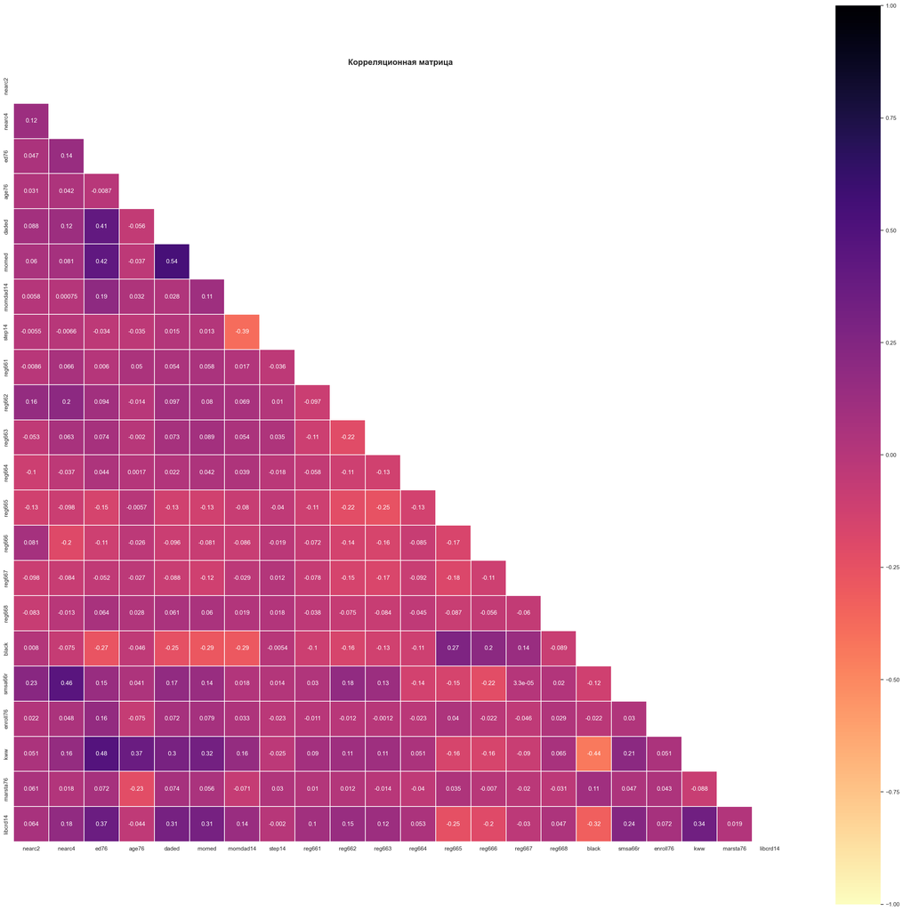

```python
corr_matrix = X_vif.corr()
sns.set(style="white")

plt.figure(figsize=(27, 25))

mask = np.triu(np.ones_like(corr_matrix, dtype=bool))

sns.heatmap(corr_matrix,
            annot=True,
            cmap='magma_r',
            # fmt='.2f',
            linewidths=0.3,
            mask=mask,
            vmin=-1,
            vmax=1,
            linecolor='white',
            square=True)
plt.title('Корреляционная матрица', fontsize=16, fontweight='bold')

plt.tight_layout()
```

#### Попробуем теперь оценить нашу модель

## Final Tuned Log-Level Linear Regression Model

```python
X = X_vif
Y = df['wage76']
Y_log = df['lwage76']

X = sm.add_constant(X)
model_log_level_tuned = sm.OLS(Y_log, X).fit(cov_type='HC3')
print(model_log_level_tuned.summary())

# Вспомним summary в R

def significance_stars(pval):
    if pval < 0.001:
        return "***"
    elif pval < 0.01:
        return "**"
    elif pval < 0.05:
        return "*"
    elif pval < 0.1:
        return "."
    else:
        return ""

results_df = pd.DataFrame({
    "Coefficient": model_log_level_tuned.params,
    "Std. Error": model_log_level_tuned.bse,
    "t-value": model_log_level_tuned.tvalues,
    "p-value": model_log_level_tuned.pvalues
})

results_df["Significance"] = results_df["p-value"].apply(significance_stars)

print(results_df)
```

```
                            OLS Regression Results
==============================================================================
Dep. Variable:                lwage76   R-squared:                       0.313
Model:                            OLS   Adj. R-squared:                  0.308
Method:                 Least Squares   F-statistic:                     63.49
Date:                Mon, 17 Mar 2025   Prob (F-statistic):          2.43e-229
Time:                        21:33:08   Log-Likelihood:                -1260.7
No. Observations:                3010   AIC:                             2567.
Df Residuals:                    2987   BIC:                             2706.
Df Model:                          22
Covariance Type:                  HC3
==============================================================================
                 coef    std err          z      P>|z|      [0.025      0.975]
------------------------------------------------------------------------------
const          4.9445      0.086     57.387      0.000       4.776       5.113
nearc2         0.0359      0.015      2.426      0.015       0.007       0.065
nearc4         0.0286      0.016      1.749      0.080      -0.003       0.061
ed76           0.0304      0.003      9.213      0.000       0.024       0.037
age76          0.0251      0.003      9.934      0.000       0.020       0.030
daded         -0.0027      0.003     -1.028      0.304      -0.008       0.002
momed          0.0055      0.003      1.899      0.058      -0.000       0.011
momdad14       0.0069      0.019      0.367      0.713      -0.030       0.044
step14        -0.0492      0.037     -1.335      0.182      -0.121       0.023
reg661        -0.1489      0.039     -3.775      0.000      -0.226      -0.072
reg662        -0.0473      0.030     -1.578      0.115      -0.106       0.011
reg663         0.0027      0.029      0.093      0.926      -0.055       0.060
reg664        -0.0966      0.037     -2.582      0.010      -0.170      -0.023
reg665        -0.1209      0.031     -3.922      0.000      -0.181      -0.060
reg666        -0.1178      0.035     -3.394      0.001      -0.186      -0.050
reg667        -0.1402      0.034     -4.094      0.000      -0.207      -0.073
reg668        -0.1859      0.046     -4.086      0.000      -0.275      -0.097
black         -0.1077      0.021     -5.180      0.000      -0.148      -0.067
smsa66r        0.0790      0.017      4.770      0.000       0.047       0.111
enroll76      -0.1258      0.026     -4.903      0.000      -0.176      -0.076
kww            0.0079      0.001      7.046      0.000       0.006       0.010
marsta76      -0.0345      0.004     -9.611      0.000      -0.042      -0.027
libcrd14       0.0238      0.016      1.447      0.148      -0.008       0.056
==============================================================================
Omnibus:                       52.248   Durbin-Watson:                   1.885
Prob(Omnibus):                  0.000   Jarque-Bera (JB):               66.365
```

[output cut: 15 more lines]

```
step14      -0.049191    0.036842  -1.335200  1.818109e-01
reg661      -0.148902    0.039440  -3.775375  1.597673e-04          ***
reg662      -0.047305    0.029977  -1.578033  1.145581e-01
reg663       0.002734    0.029300   0.093310  9.256577e-01
reg664      -0.096552    0.037401  -2.581538  9.836115e-03           **
reg665      -0.120909    0.030825  -3.922470  8.764596e-05          ***
reg666      -0.117812    0.034715  -3.393675  6.896156e-04          ***
reg667      -0.140191    0.034243  -4.094047  4.239078e-05          ***
reg668      -0.185950    0.045509  -4.086018  4.388398e-05          ***
black       -0.107724    0.020798  -5.179598  2.223652e-07          ***
smsa66r      0.079017    0.016567   4.769565  1.846244e-06          ***
enroll76    -0.125836    0.025664  -4.903215  9.428065e-07          ***
kww          0.007891    0.001120   7.045933  1.842226e-12          ***
marsta76    -0.034524    0.003592  -9.611075  7.179538e-22          ***
libcrd14     0.023845    0.016485   1.446535  1.480273e-01
```

#### Получилось! Мы смогли справиться с плохой обусловленностью задачи.

```python
# Перегоню обратно из логарифма
Y_true = Y
plot_data = pd.DataFrame()
plot_data['Y_pred'] = np.exp(model_log_level_tuned.predict(X))
plot_data['Y_true'] = Y_true
plot_data.head(2)
```

|  | Y_pred | Y_true |
| --- | --- | --- |
| 0 | 339.542036 | 548.0 |
| 1 | 498.563223 | 481.0 |

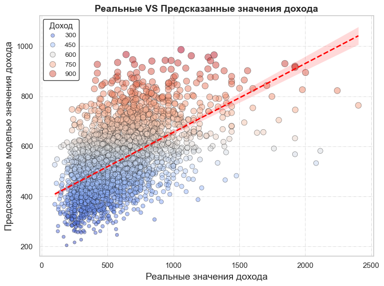

```python
# plt.figure(figsize=(6, 5))
plt.figure(figsize=(8, 6))


sns.set_style("whitegrid")
palette = sns.color_palette("coolwarm", as_cmap=True)


sns.scatterplot(data=plot_data,
                x='Y_true',
                y='Y_pred',
                hue='Y_pred',
                palette=palette,
                size="Y_pred",
                sizes=(20, 100),
                s=80,
                alpha=0.5,
                edgecolor="black",
                linewidth=0.5
                # marker='o'
)

sns.regplot(data=plot_data,
            x='Y_true',
            y='Y_pred',
            scatter=False,
            # order=2,
            # lowess=True,
            color='red',
            line_kws={'linewidth': 2, 'linestyle': '--'}
           )

# sns.stripplot(data=df, x='employ', y='income', jitter=True, alpha=0.3)

plt.title('Реальные VS Предсказанные значения дохода', fontsize=14, fontweight='bold')
plt.xlabel('Реальные значения дохода', fontsize=14)
plt.ylabel('Предсказанные моделью значения дохода', fontsize=14)
# plt.xticks(fontsize=10)
# plt.yticks(fontsize=10)


plt.grid(True, linestyle='-.', linewidth=0.7, alpha=0.7)
# plt.grid(True, which='both', linestyle='--', alpha=0.5)
plt.legend(title="Доход", fontsize=10, title_fontsize=12, frameon=True, edgecolor="black", facecolor="white")

plt.tight_layout()
```

# **Глобальные выводы:**

### Интерпретация модели

#### 1. Качество модели

- **R² = 0.313**: модель объясняет 31.3% дисперсии логарифма заработной платы в 1976 году.
- **Adj. R² = 0.308**: учитывая количество предикторов, объясненная дисперсия немного снижается.
- **F-статистика = 63.49, p < 0.001**: модель статистически значима в целом.
- **cond. number (651)** указывает на отсутствие серьезных проблем мультиколлинеарности.

#### 2. Влияние ключевых переменных

- **Образование (ed76)**: каждый дополнительный год обучения увеличивает логарифм зарплаты на **0.0304 (3,04%)**, эффект значим на уровне **p < 0.001**.
- **Возраст (age76)**: с увеличением возраста логарифм зарплаты растет на **0.0251 (2,51%)** за год (p < 0.001).
- **Родители (daded, momed)**: образование отца незначимо (p = 0.304), а образование матери имеет слабый положительный эффект (p = 0.058).
- **Жизненные условия в 14 лет (momdad14, step14)**: оба коэффициента незначимы, влияние отсутствует.
- **Региональные эффекты (reg66x)**: ряд регионов (661, 664, 665, 666, 667, 668) оказывают отрицательное и статистически значимое влияние.
- **Признак black**: отрицательный и значимый коэффициент (-0.1077, p < 0.001) указывает на разницу в оплате труда.
- **Проживание в городской местности в 1966 (smsa66r)**: положительный и значимый эффект (0.0790, p < 0.001).
- **Когнитивные способности (kww)**: значимый положительный эффект (0.0079, p < 0.001).
- **Семейное положение (marsta76)**: отрицательный и значимый эффект (-0.0345, p < 0.001).

#### 3. Выводы

- Основными факторами, влияющими на заработную плату, являются **образование, возраст, место проживания, расовая принадлежность и когнитивные способности**.
- Чернокожие работники в среднем зарабатывают меньше, даже с учетом других факторов.
- Городское проживание в 1966 году и когнитивные навыки положительн коррелируют с зарплатой.

### **Исследовательская гипотеза**

"При увеличении уровня образования человека, соответствующе в некотором измерении растет его заработная плата. Расовая дискриминация как институциональная проблема существовала на горизонте сбора данных".

**Гипотеза подтверждается**.

- Чем более человек образованный, тем больше он имеет заработную плату;
- Этнически афроамериканское население в среднем зарабатывает меньше, чем население с европиоидным происхождением. Потенциально, расовая дискриминация на институциональном уровне и правда существовала.